# examples_0402

A large square comprises a yellow square, two congruent blue rectangles, and a red square.

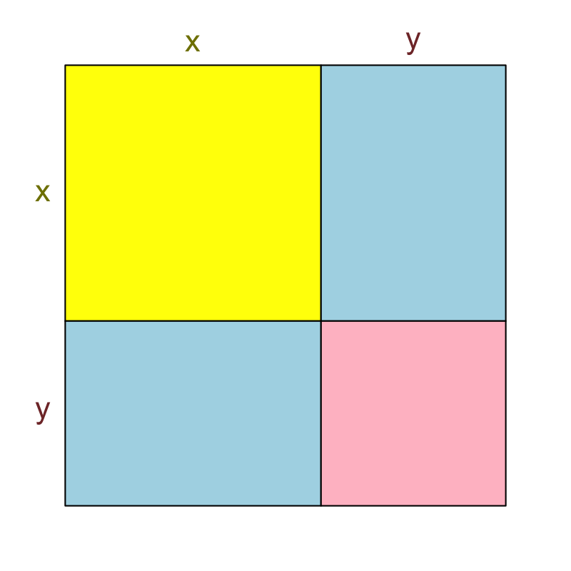

The yellow square has an area of $x^2$ square units. The two blue rectangles have a combined area of $26x$ square units.

What is the area, in square units, of the red square?

Find the area of each blue rectangle.

$$B=\frac{26x}{2}$$
$$B=13x$$

Each blue rectangle has one length of $x$ and another of length $13$.

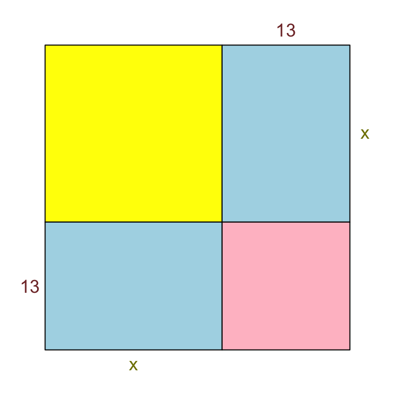

The red square has side lengths equal to $y=13$. To find its area, square the side length.

$$R=y^2$$
$$R=13^2$$
$$R=169$$

The area of the red square is 169 square units.

A large square comprises a yellow square, two congruent blue rectangles, and a red square.

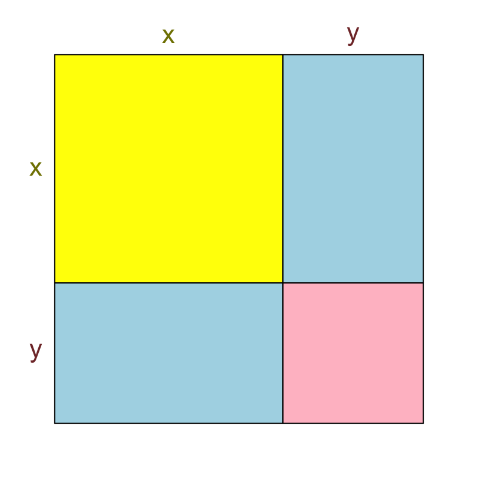

The yellow square has an area of $x^2$ square units. The two blue rectangles have a combined area of $16x$ square units.

What is the area, in square units, of the red square?

Find the area of each blue rectangle.

$$B=\frac{16x}{2}$$
$$B=8x$$

Each blue rectangle has one length of $x$ and another of length $8$.

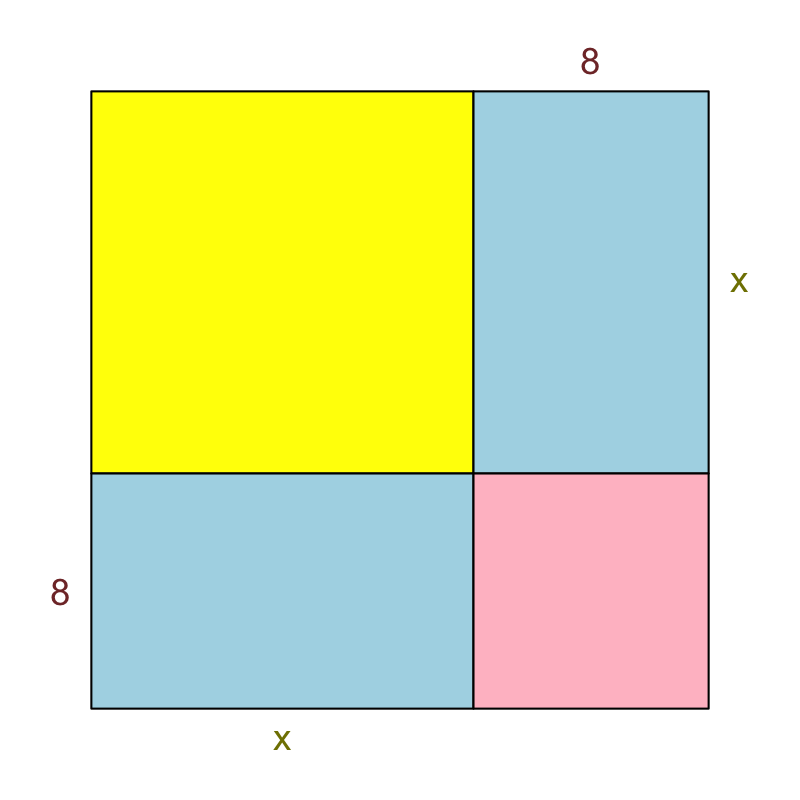

The red square has side lengths equal to $y=8$. To find its area, square the side length.

$$R=y^2$$
$$R=8^2$$
$$R=64$$

The area of the red square is 64 square units.

A wrap-around L-shaped patio will measure 29 feet along both walls. The patio will stick out $x$ feet from the walls, and the total area will be 759 square feet. *Note: you can assume all angles are right angles.*

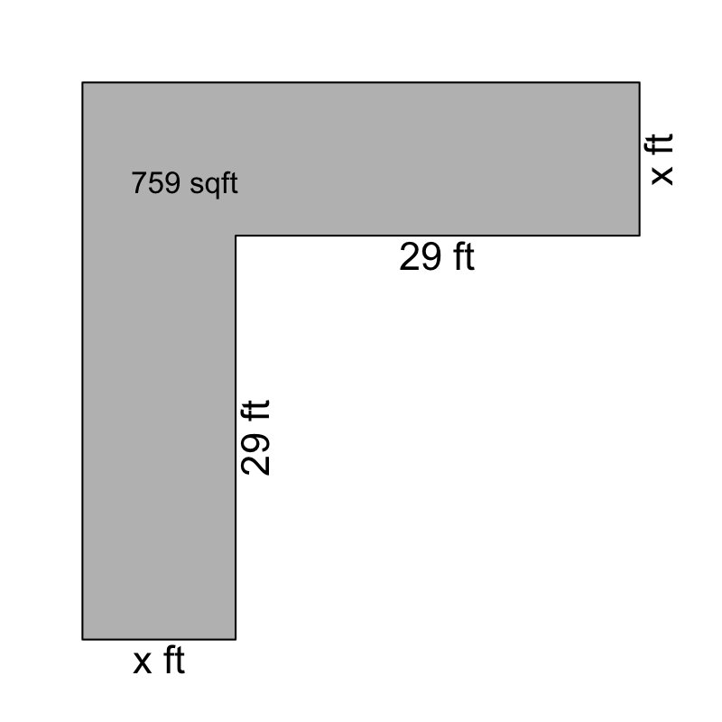

What value of $x$ satisfies the conditions stated above?

We can write an equation by saying the sum of $x^2$ and $29x$ and $29x$ equals 759. These expressions represent the areas of a small square and two rectangles.

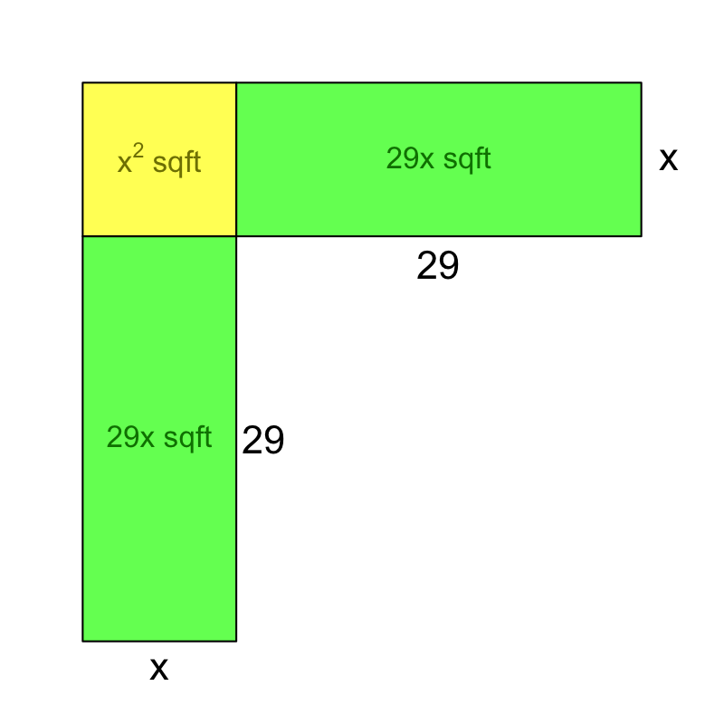

$$x^2+29x+29x~=~759$$

Combine like terms.

$$x^2+58x~=~759$$

There is a fun way to solve this. We will "complete the square". In this situation, the means we can imagine adding some extra area to the picture to make a large square. In this case, we need to add a square with edge lengths of 29, adding 841 square feet to the area.

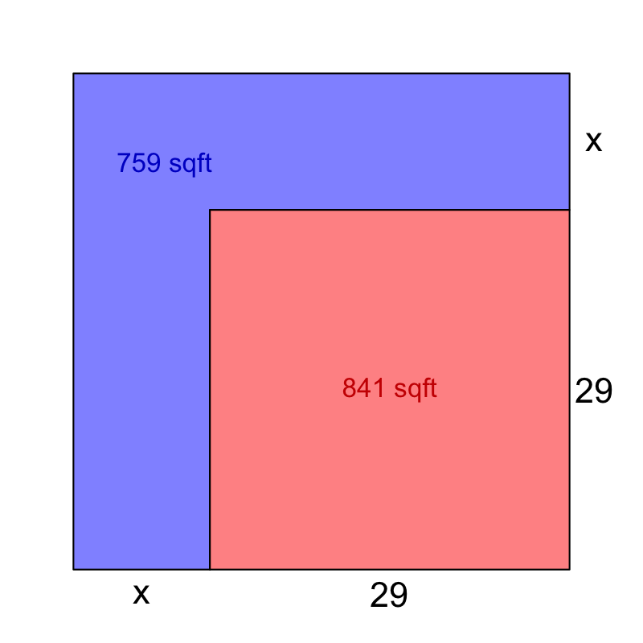

$$x^2+58x+841~=~759+841$$

$$x^2+58x+841~=~1600$$

But, notice, if you look at the last picture, we have another way to represent the total area. The newly formed large square has side lengths of $x+29$. So we can represent the total area of the large square as $(x+29)^2$.

$$(x+29)^2~=~1600$$

We can now use the square-root operation on both sides of the equation.

$$\sqrt{(x+29)^2}~=~\sqrt{1600}$$

$$x+29~=~40$$

And, lastly, subtract 29 from both sides of the equation.

$$x~=~40-29$$

$$x~=~11$$

A wrap-around L-shaped patio will measure 12 feet along both walls. The patio will stick out $x$ feet from the walls, and the total area will be 340 square feet. *Note: you can assume all angles are right angles.*

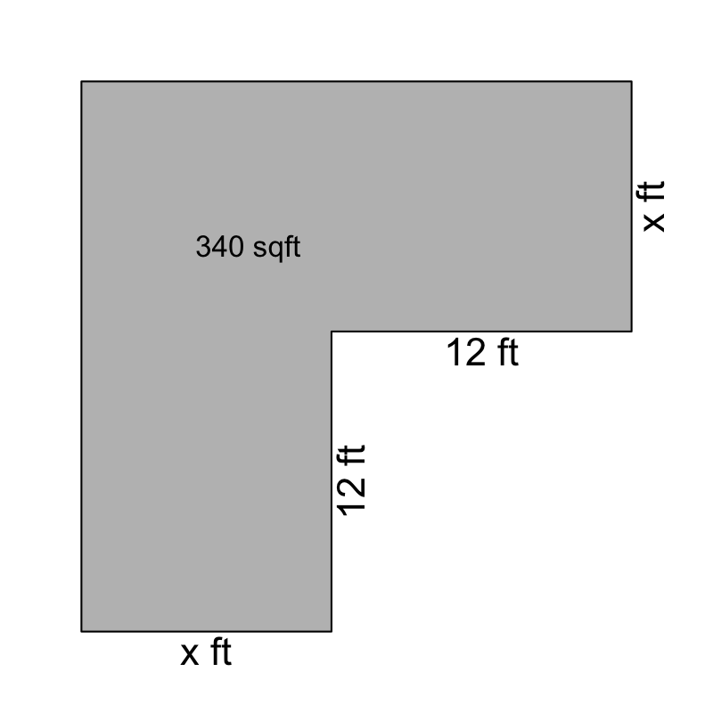

What value of $x$ satisfies the conditions stated above?

We can write an equation by saying the sum of $x^2$ and $12x$ and $12x$ equals 340. These expressions represent the areas of a small square and two rectangles.

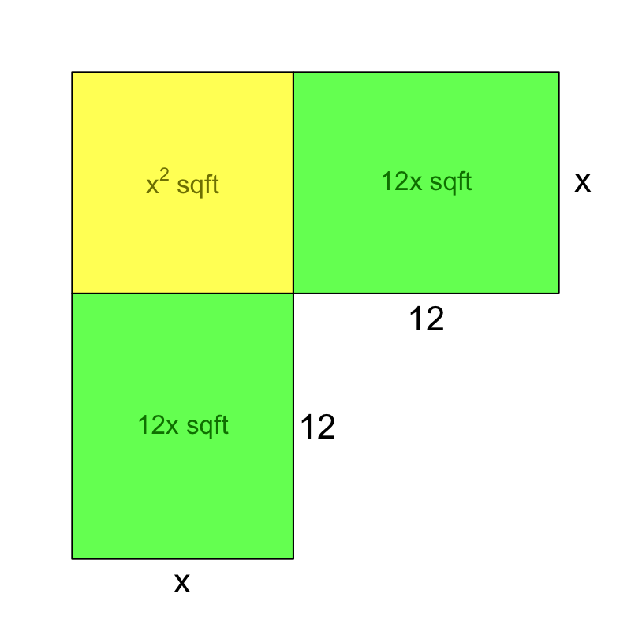

$$x^2+12x+12x~=~340$$

Combine like terms.

$$x^2+24x~=~340$$

There is a fun way to solve this. We will "complete the square". In this situation, the means we can imagine adding some extra area to the picture to make a large square. In this case, we need to add a square with edge lengths of 12, adding 144 square feet to the area.

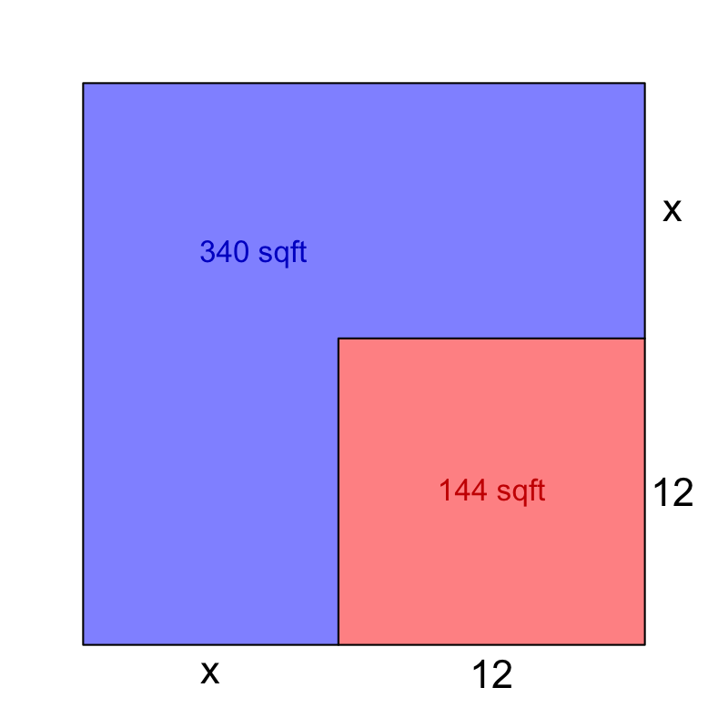

$$x^2+24x+144~=~340+144$$

$$x^2+24x+144~=~484$$

But, notice, if you look at the last picture, we have another way to represent the total area. The newly formed large square has side lengths of $x+12$. So we can represent the total area of the large square as $(x+12)^2$.

$$(x+12)^2~=~484$$

We can now use the square-root operation on both sides of the equation.

$$\sqrt{(x+12)^2}~=~\sqrt{484}$$

$$x+12~=~22$$

And, lastly, subtract 12 from both sides of the equation.

$$x~=~22-12$$

$$x~=~10$$

A wrap-around L-shaped patio will measure 20 feet along both walls. The patio will stick out $x$ feet from the walls, and the total area will be 756 square feet. *Note: you can assume all angles are right angles.*

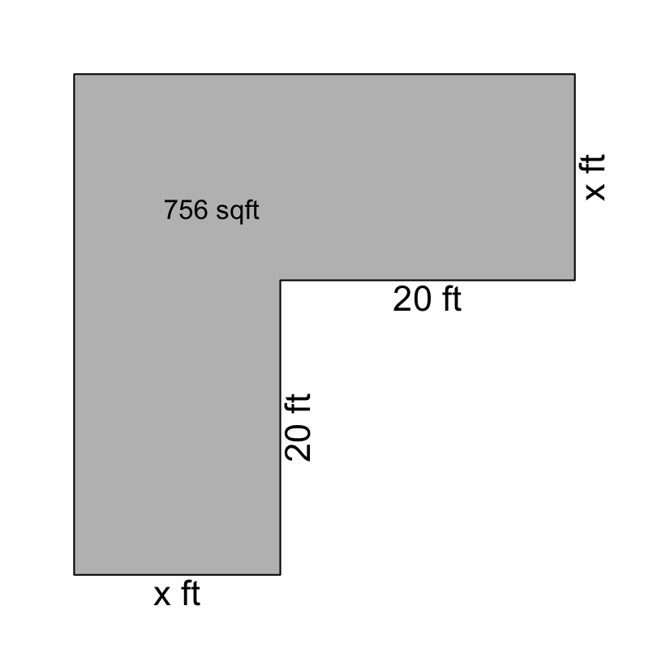

What value of $x$ satisfies the conditions stated above?

We can write an equation by saying the sum of $x^2$ and $20x$ and $20x$ equals 756. These expressions represent the areas of a small square and two rectangles.

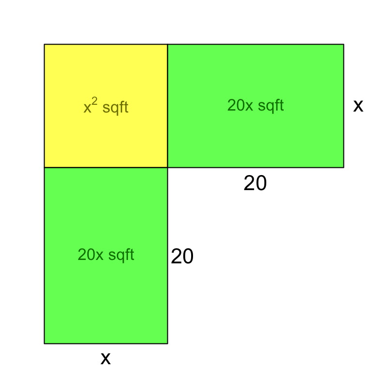

$$x^2+20x+20x~=~756$$

Combine like terms.

$$x^2+40x~=~756$$

There is a fun way to solve this. We will "complete the square". In this situation, the means we can imagine adding some extra area to the picture to make a large square. In this case, we need to add a square with edge lengths of 20, adding 400 square feet to the area.

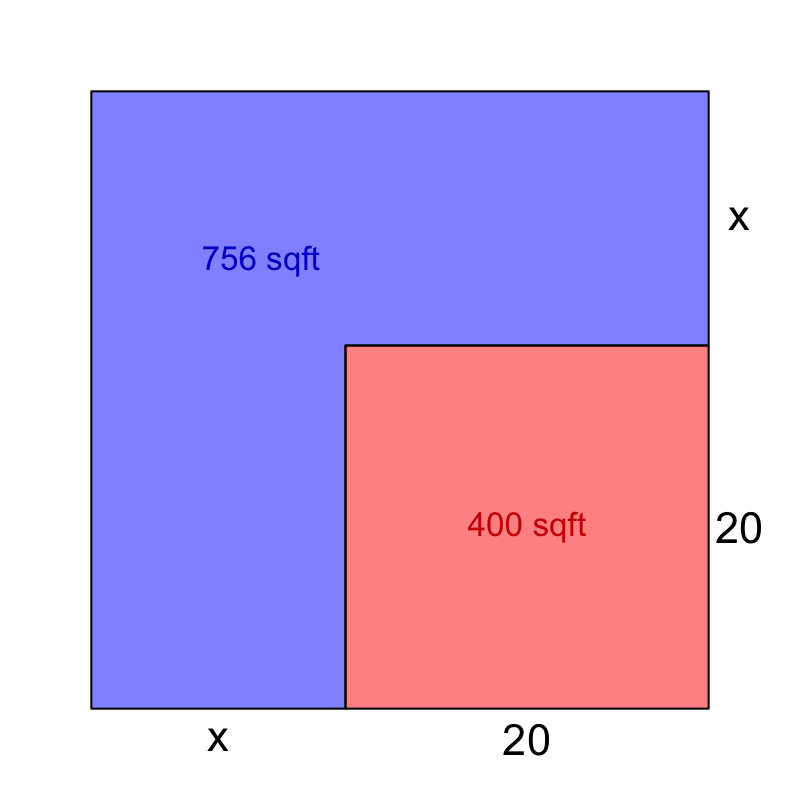

$$x^2+40x+400~=~756+400$$

$$x^2+40x+400~=~1156$$

But, notice, if you look at the last picture, we have another way to represent the total area. The newly formed large square has side lengths of $x+20$. So we can represent the total area of the large square as $(x+20)^2$.

$$(x+20)^2~=~1156$$

We can now use the square-root operation on both sides of the equation.

$$\sqrt{(x+20)^2}~=~\sqrt{1156}$$

$$x+20~=~34$$

And, lastly, subtract 20 from both sides of the equation.

$$x~=~34-20$$

$$x~=~14$$

A wrap-around L-shaped patio will measure 30 feet along both walls. The patio will stick out $x$ feet from the walls, and the total area will be 1909 square feet. *Note: you can assume all angles are right angles.*

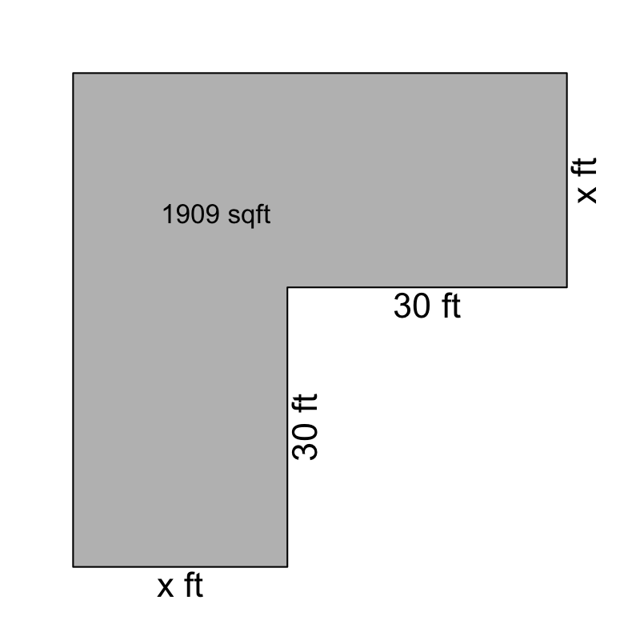

What value of $x$ satisfies the conditions stated above?

We can write an equation by saying the sum of $x^2$ and $30x$ and $30x$ equals 1909. These expressions represent the areas of a small square and two rectangles.

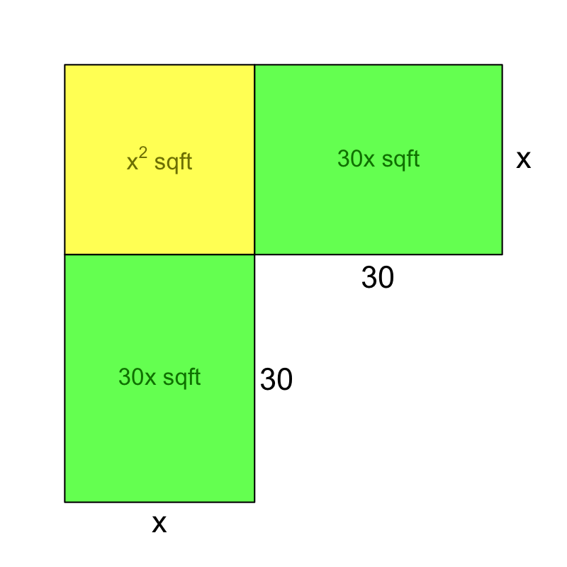

$$x^2+30x+30x~=~1909$$

Combine like terms.

$$x^2+60x~=~1909$$

There is a fun way to solve this. We will "complete the square". In this situation, the means we can imagine adding some extra area to the picture to make a large square. In this case, we need to add a square with edge lengths of 30, adding 900 square feet to the area.

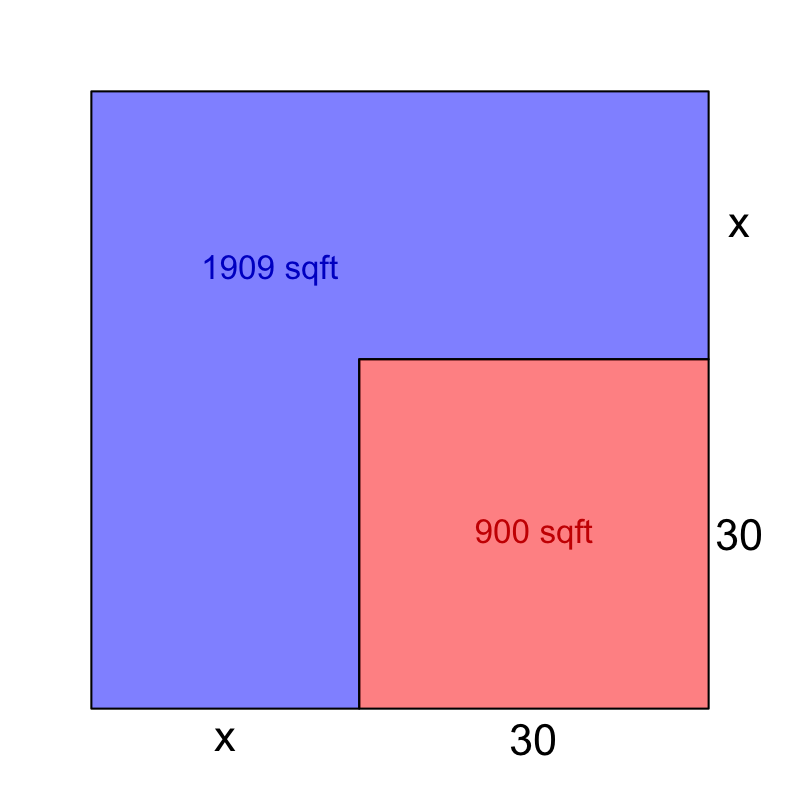

$$x^2+60x+900~=~1909+900$$

$$x^2+60x+900~=~2809$$

But, notice, if you look at the last picture, we have another way to represent the total area. The newly formed large square has side lengths of $x+30$. So we can represent the total area of the large square as $(x+30)^2$.

$$(x+30)^2~=~2809$$

We can now use the square-root operation on both sides of the equation.

$$\sqrt{(x+30)^2}~=~\sqrt{2809}$$

$$x+30~=~53$$

And, lastly, subtract 30 from both sides of the equation.

$$x~=~53-30$$

$$x~=~23$$

A wrap-around L-shaped patio will measure 23 feet along both walls. The patio will stick out $x$ feet from the walls, and the total area will be 840 square feet. *Note: you can assume all angles are right angles.*

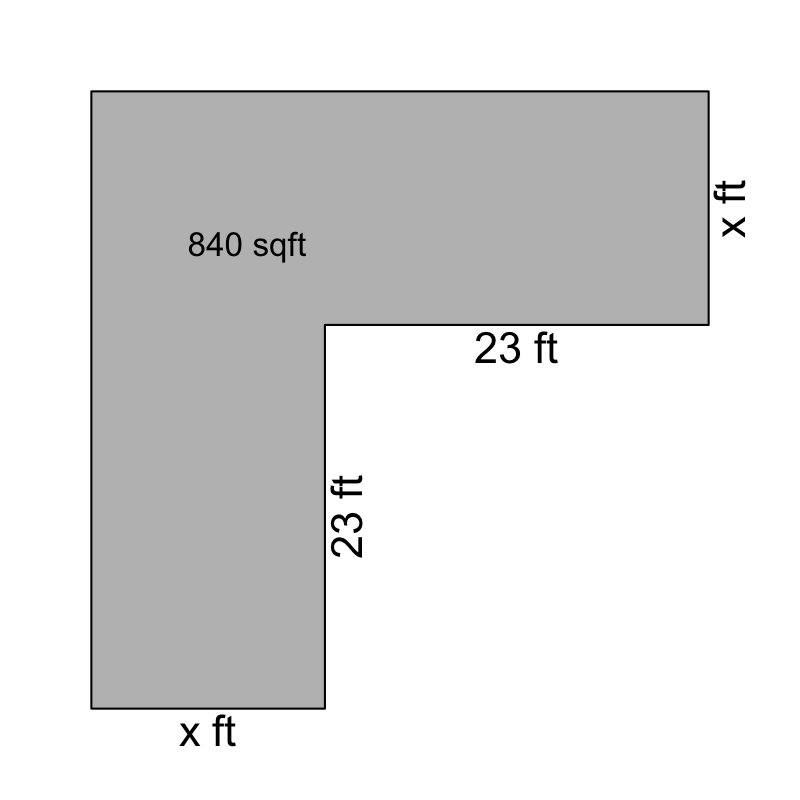

What value of $x$ satisfies the conditions stated above?

We can write an equation by saying the sum of $x^2$ and $23x$ and $23x$ equals 840. These expressions represent the areas of a small square and two rectangles.

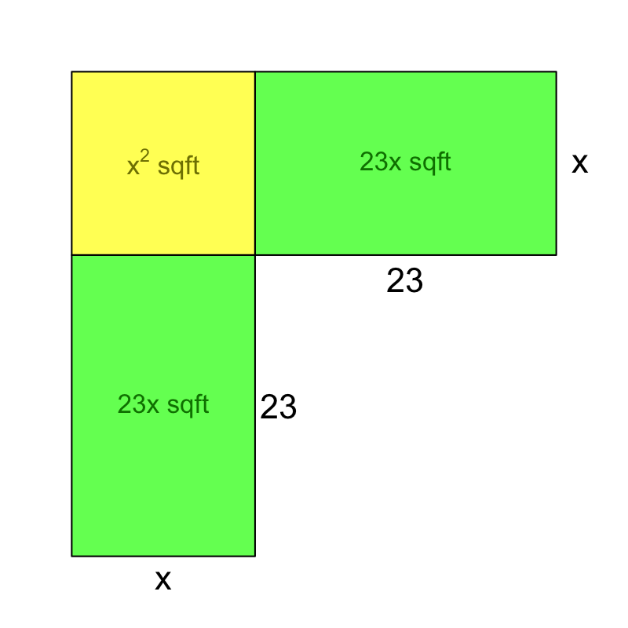

$$x^2+23x+23x~=~840$$

Combine like terms.

$$x^2+46x~=~840$$

There is a fun way to solve this. We will "complete the square". In this situation, the means we can imagine adding some extra area to the picture to make a large square. In this case, we need to add a square with edge lengths of 23, adding 529 square feet to the area.

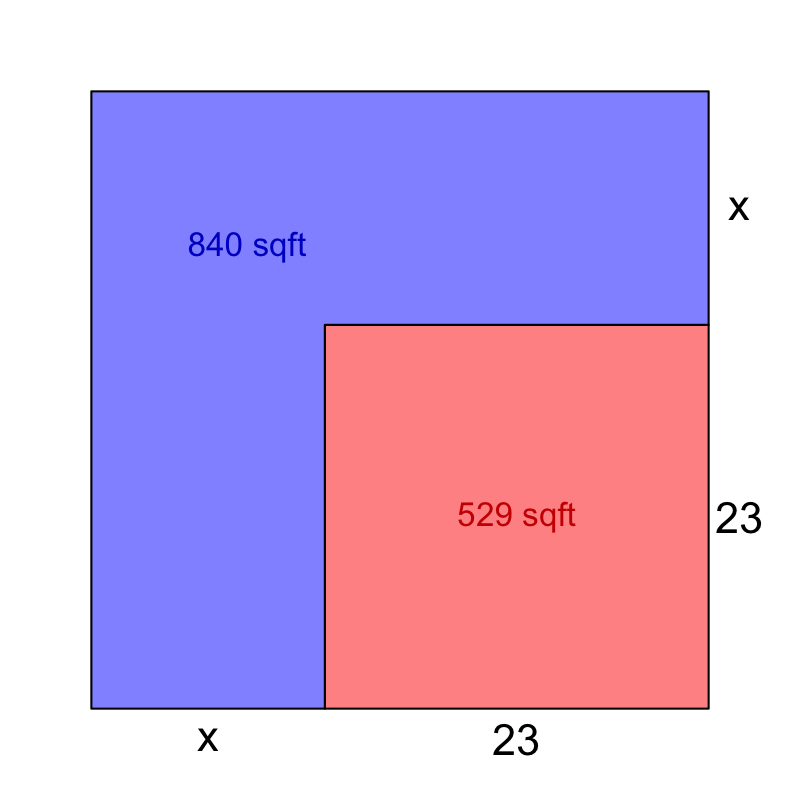

$$x^2+46x+529~=~840+529$$

$$x^2+46x+529~=~1369$$

But, notice, if you look at the last picture, we have another way to represent the total area. The newly formed large square has side lengths of $x+23$. So we can represent the total area of the large square as $(x+23)^2$.

$$(x+23)^2~=~1369$$

We can now use the square-root operation on both sides of the equation.

$$\sqrt{(x+23)^2}~=~\sqrt{1369}$$

$$x+23~=~37$$

And, lastly, subtract 23 from both sides of the equation.

$$x~=~37-23$$

$$x~=~14$$

A wrap-around L-shaped patio will measure 25 feet along both walls. The patio will stick out $x$ feet from the walls, and the total area will be 744 square feet. *Note: you can assume all angles are right angles.*

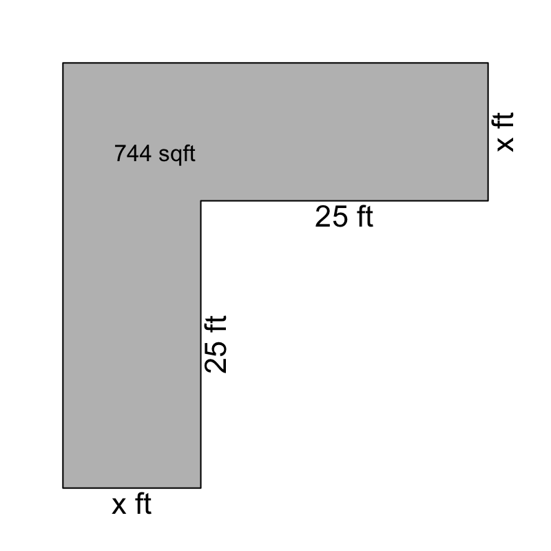

What value of $x$ satisfies the conditions stated above?

We can write an equation by saying the sum of $x^2$ and $25x$ and $25x$ equals 744. These expressions represent the areas of a small square and two rectangles.

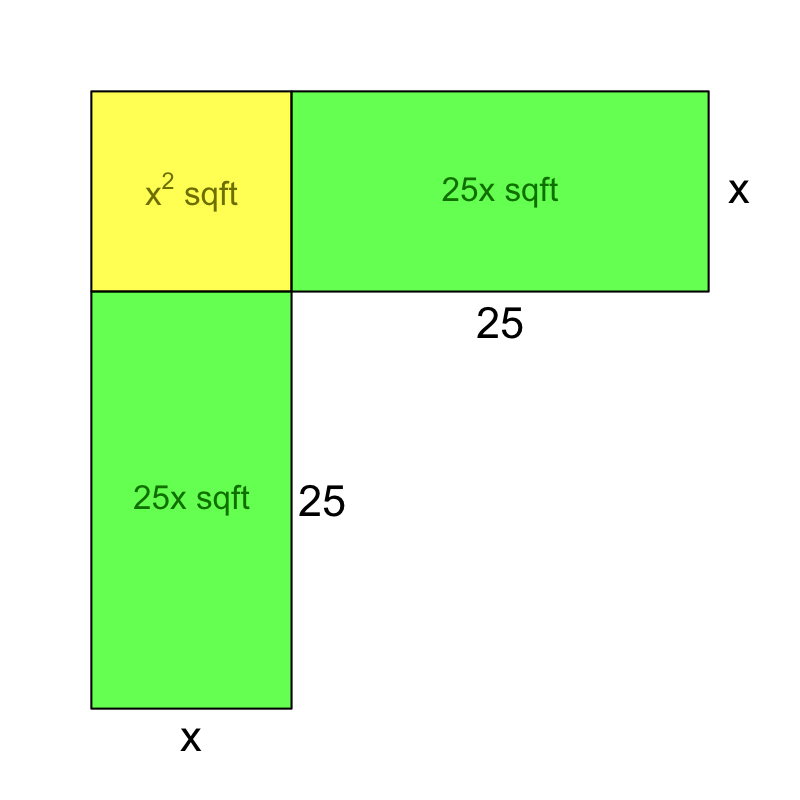

$$x^2+25x+25x~=~744$$

Combine like terms.

$$x^2+50x~=~744$$

There is a fun way to solve this. We will "complete the square". In this situation, the means we can imagine adding some extra area to the picture to make a large square. In this case, we need to add a square with edge lengths of 25, adding 625 square feet to the area.

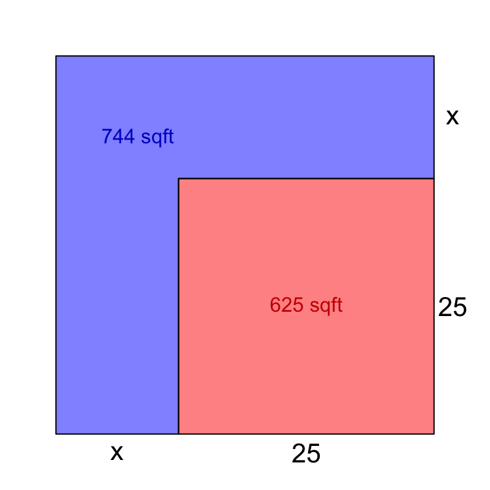

$$x^2+50x+625~=~744+625$$

$$x^2+50x+625~=~1369$$

But, notice, if you look at the last picture, we have another way to represent the total area. The newly formed large square has side lengths of $x+25$. So we can represent the total area of the large square as $(x+25)^2$.

$$(x+25)^2~=~1369$$

We can now use the square-root operation on both sides of the equation.

$$\sqrt{(x+25)^2}~=~\sqrt{1369}$$

$$x+25~=~37$$

And, lastly, subtract 25 from both sides of the equation.

$$x~=~37-25$$

$$x~=~12$$

A wrap-around L-shaped patio will measure 19 feet along both walls. The patio will stick out $x$ feet from the walls, and the total area will be 480 square feet. *Note: you can assume all angles are right angles.*

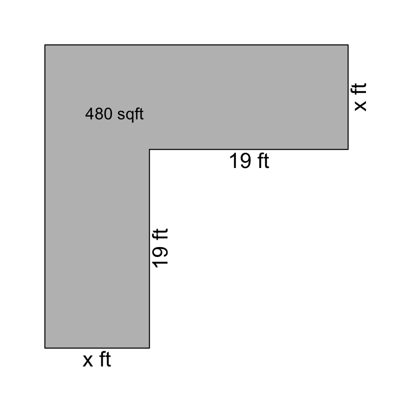

What value of $x$ satisfies the conditions stated above?

We can write an equation by saying the sum of $x^2$ and $19x$ and $19x$ equals 480. These expressions represent the areas of a small square and two rectangles.

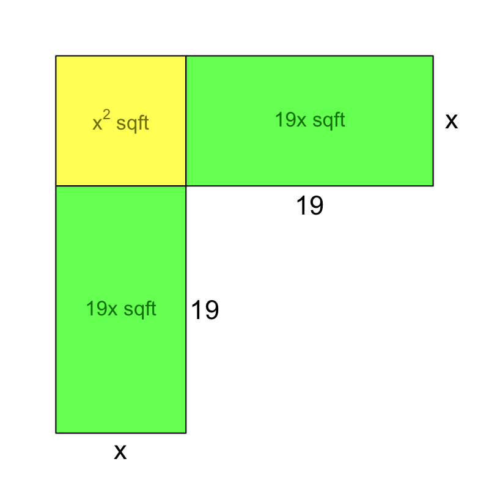

$$x^2+19x+19x~=~480$$

Combine like terms.

$$x^2+38x~=~480$$

There is a fun way to solve this. We will "complete the square". In this situation, the means we can imagine adding some extra area to the picture to make a large square. In this case, we need to add a square with edge lengths of 19, adding 361 square feet to the area.

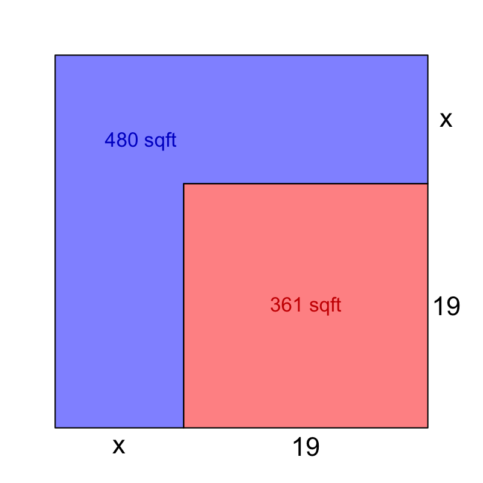

$$x^2+38x+361~=~480+361$$

$$x^2+38x+361~=~841$$

But, notice, if you look at the last picture, we have another way to represent the total area. The newly formed large square has side lengths of $x+19$. So we can represent the total area of the large square as $(x+19)^2$.

$$(x+19)^2~=~841$$

We can now use the square-root operation on both sides of the equation.

$$\sqrt{(x+19)^2}~=~\sqrt{841}$$

$$x+19~=~29$$

And, lastly, subtract 19 from both sides of the equation.

$$x~=~29-19$$

$$x~=~10$$

A wrap-around L-shaped patio will measure 27 feet along both walls. The patio will stick out $x$ feet from the walls, and the total area will be 1207 square feet. *Note: you can assume all angles are right angles.*

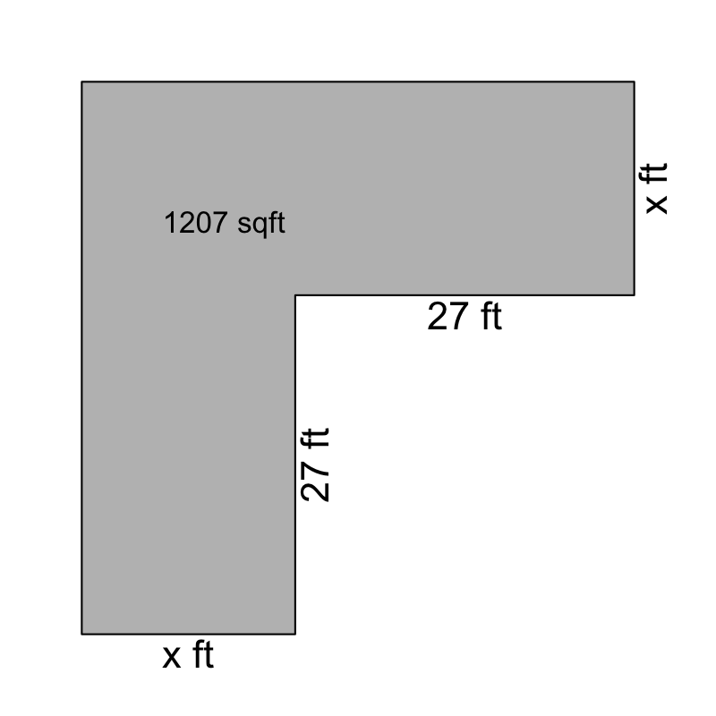

What value of $x$ satisfies the conditions stated above?

We can write an equation by saying the sum of $x^2$ and $27x$ and $27x$ equals 1207. These expressions represent the areas of a small square and two rectangles.

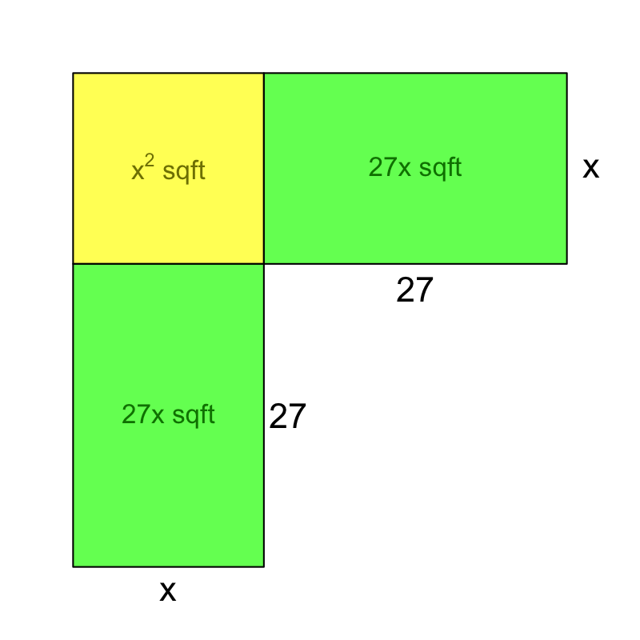

$$x^2+27x+27x~=~1207$$

Combine like terms.

$$x^2+54x~=~1207$$

There is a fun way to solve this. We will "complete the square". In this situation, the means we can imagine adding some extra area to the picture to make a large square. In this case, we need to add a square with edge lengths of 27, adding 729 square feet to the area.

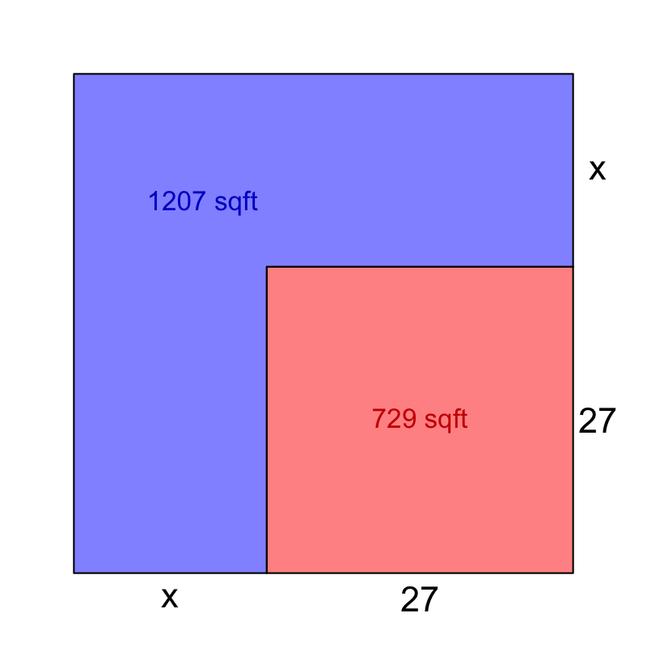

$$x^2+54x+729~=~1207+729$$

$$x^2+54x+729~=~1936$$

But, notice, if you look at the last picture, we have another way to represent the total area. The newly formed large square has side lengths of $x+27$. So we can represent the total area of the large square as $(x+27)^2$.

$$(x+27)^2~=~1936$$

We can now use the square-root operation on both sides of the equation.

$$\sqrt{(x+27)^2}~=~\sqrt{1936}$$

$$x+27~=~44$$

And, lastly, subtract 27 from both sides of the equation.

$$x~=~44-27$$

$$x~=~17$$

A wrap-around L-shaped patio will measure 19 feet along both walls. The patio will stick out $x$ feet from the walls, and the total area will be 1008 square feet. *Note: you can assume all angles are right angles.*

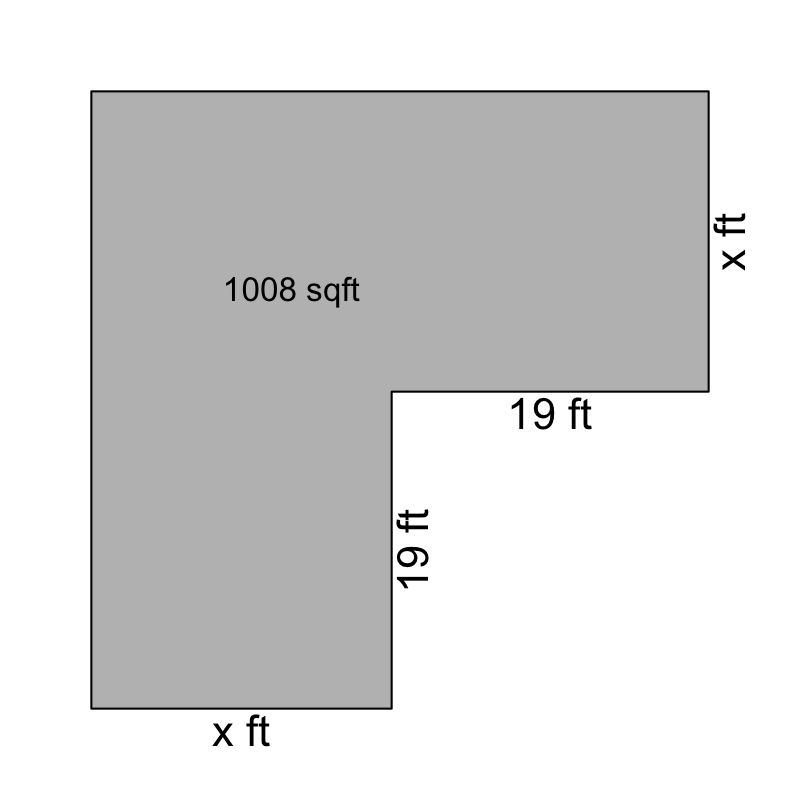

What value of $x$ satisfies the conditions stated above?

We can write an equation by saying the sum of $x^2$ and $19x$ and $19x$ equals 1008. These expressions represent the areas of a small square and two rectangles.

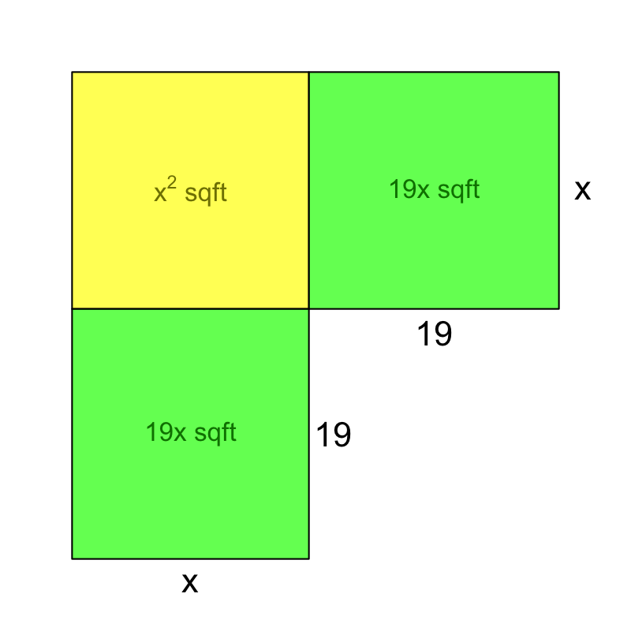

$$x^2+19x+19x~=~1008$$

Combine like terms.

$$x^2+38x~=~1008$$

There is a fun way to solve this. We will "complete the square". In this situation, the means we can imagine adding some extra area to the picture to make a large square. In this case, we need to add a square with edge lengths of 19, adding 361 square feet to the area.

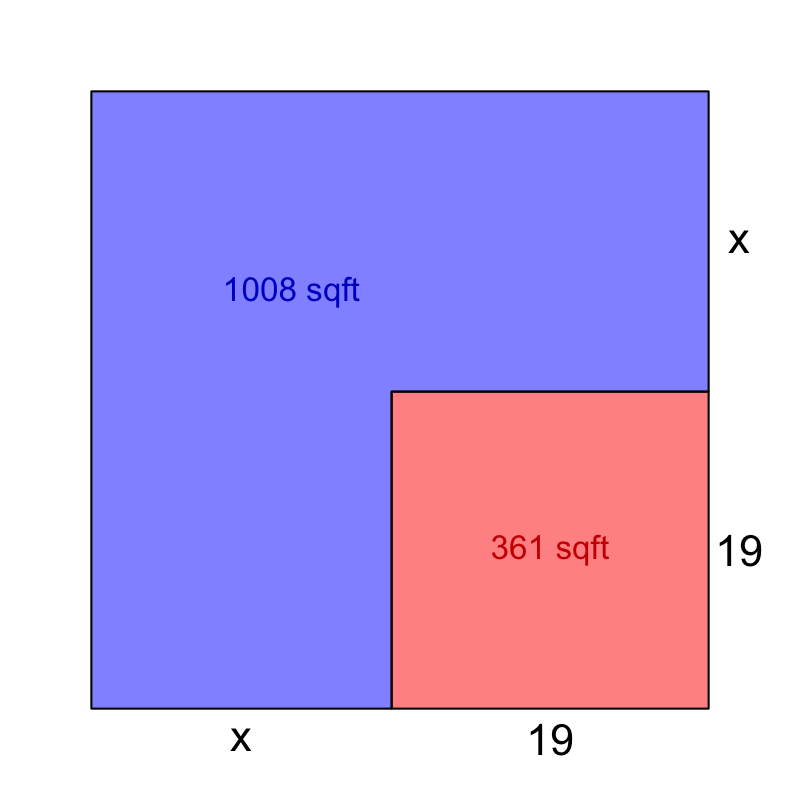

$$x^2+38x+361~=~1008+361$$

$$x^2+38x+361~=~1369$$

But, notice, if you look at the last picture, we have another way to represent the total area. The newly formed large square has side lengths of $x+19$. So we can represent the total area of the large square as $(x+19)^2$.

$$(x+19)^2~=~1369$$

We can now use the square-root operation on both sides of the equation.

$$\sqrt{(x+19)^2}~=~\sqrt{1369}$$

$$x+19~=~37$$

And, lastly, subtract 19 from both sides of the equation.

$$x~=~37-19$$

$$x~=~18$$

A wrap-around L-shaped patio will measure 30 feet along both walls. The patio will stick out $x$ feet from the walls, and the total area will be 949 square feet. *Note: you can assume all angles are right angles.*

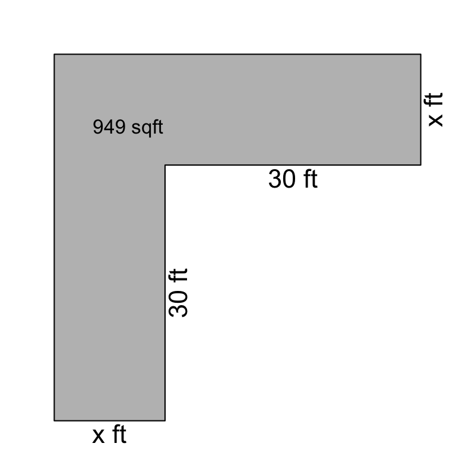

What value of $x$ satisfies the conditions stated above?

We can write an equation by saying the sum of $x^2$ and $30x$ and $30x$ equals 949. These expressions represent the areas of a small square and two rectangles.

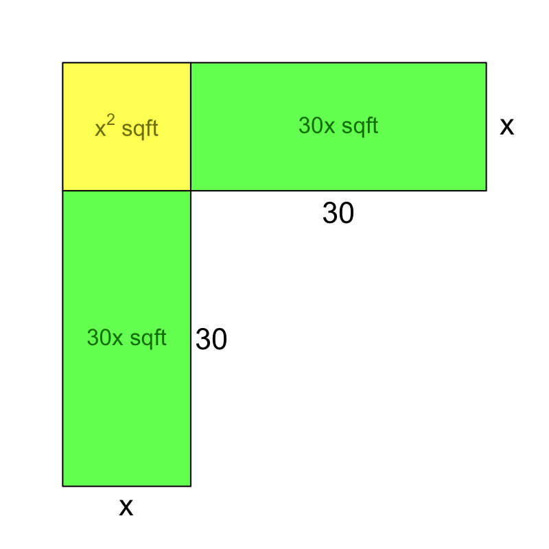

$$x^2+30x+30x~=~949$$

Combine like terms.

$$x^2+60x~=~949$$

There is a fun way to solve this. We will "complete the square". In this situation, the means we can imagine adding some extra area to the picture to make a large square. In this case, we need to add a square with edge lengths of 30, adding 900 square feet to the area.

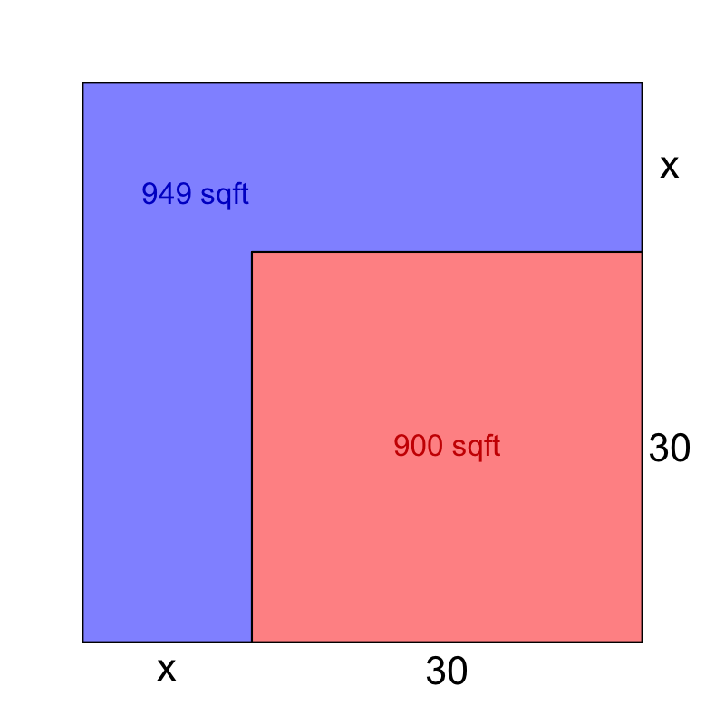

$$x^2+60x+900~=~949+900$$

$$x^2+60x+900~=~1849$$

But, notice, if you look at the last picture, we have another way to represent the total area. The newly formed large square has side lengths of $x+30$. So we can represent the total area of the large square as $(x+30)^2$.

$$(x+30)^2~=~1849$$

We can now use the square-root operation on both sides of the equation.

$$\sqrt{(x+30)^2}~=~\sqrt{1849}$$

$$x+30~=~43$$

And, lastly, subtract 30 from both sides of the equation.

$$x~=~43-30$$

$$x~=~13$$

A wrap-around L-shaped patio will measure 26 feet along both walls. The patio will stick out $x$ feet from the walls, and the total area will be 1173 square feet. *Note: you can assume all angles are right angles.*

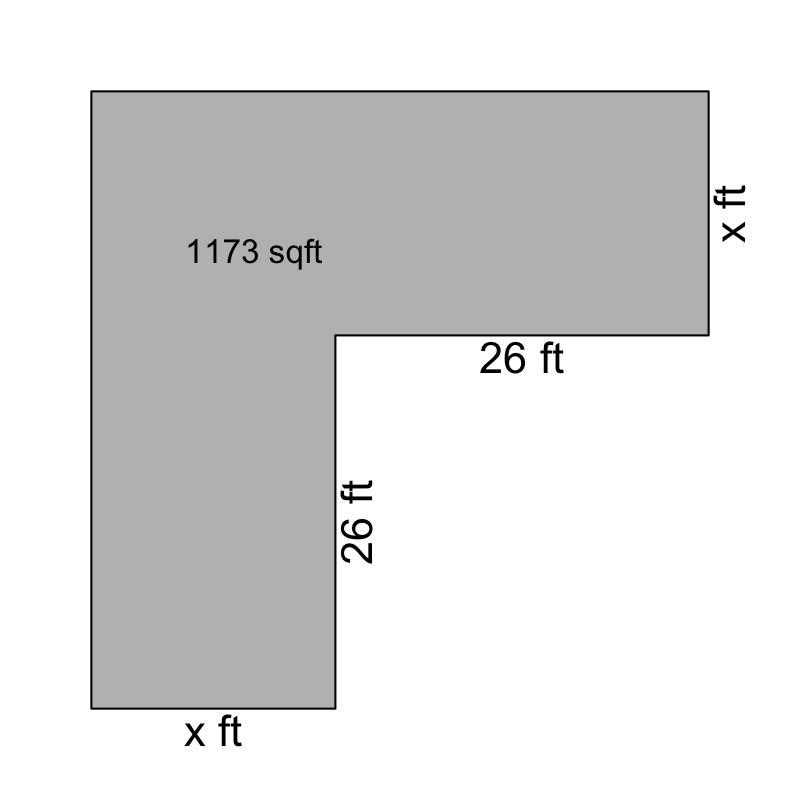

What value of $x$ satisfies the conditions stated above?

We can write an equation by saying the sum of $x^2$ and $26x$ and $26x$ equals 1173. These expressions represent the areas of a small square and two rectangles.

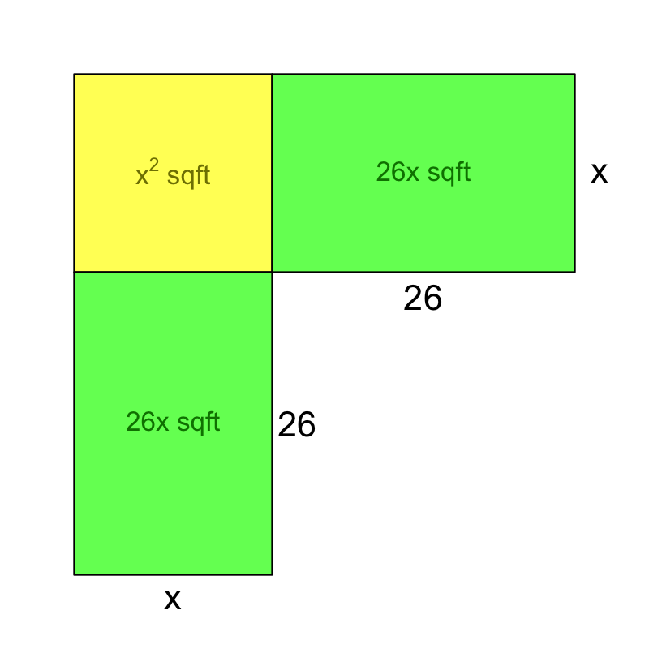

$$x^2+26x+26x~=~1173$$

Combine like terms.

$$x^2+52x~=~1173$$

There is a fun way to solve this. We will "complete the square". In this situation, the means we can imagine adding some extra area to the picture to make a large square. In this case, we need to add a square with edge lengths of 26, adding 676 square feet to the area.

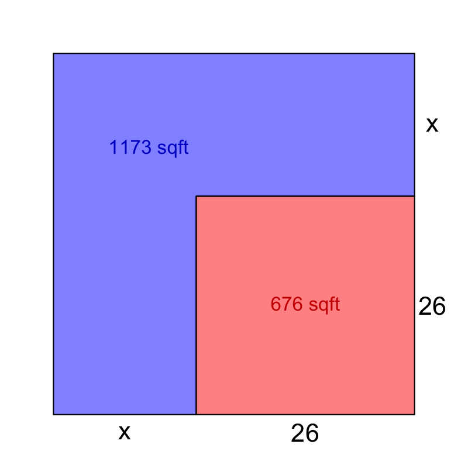

$$x^2+52x+676~=~1173+676$$

$$x^2+52x+676~=~1849$$

But, notice, if you look at the last picture, we have another way to represent the total area. The newly formed large square has side lengths of $x+26$. So we can represent the total area of the large square as $(x+26)^2$.

$$(x+26)^2~=~1849$$

We can now use the square-root operation on both sides of the equation.

$$\sqrt{(x+26)^2}~=~\sqrt{1849}$$

$$x+26~=~43$$

And, lastly, subtract 26 from both sides of the equation.

$$x~=~43-26$$

$$x~=~17$$

A wrap-around L-shaped patio will measure 23 feet along both walls. The patio will stick out $x$ feet from the walls, and the total area will be 915 square feet. *Note: you can assume all angles are right angles.*

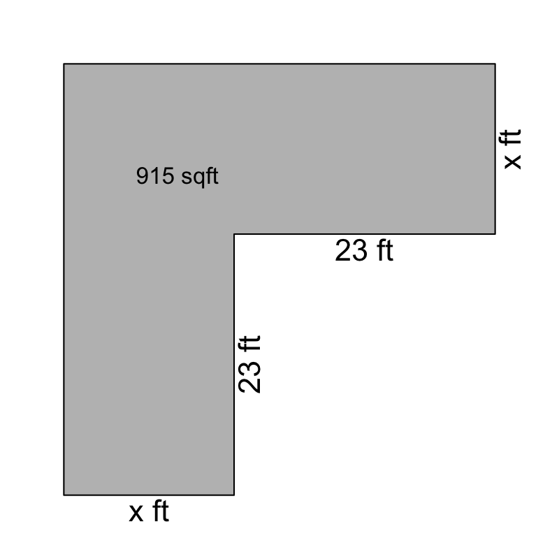

What value of $x$ satisfies the conditions stated above?

We can write an equation by saying the sum of $x^2$ and $23x$ and $23x$ equals 915. These expressions represent the areas of a small square and two rectangles.

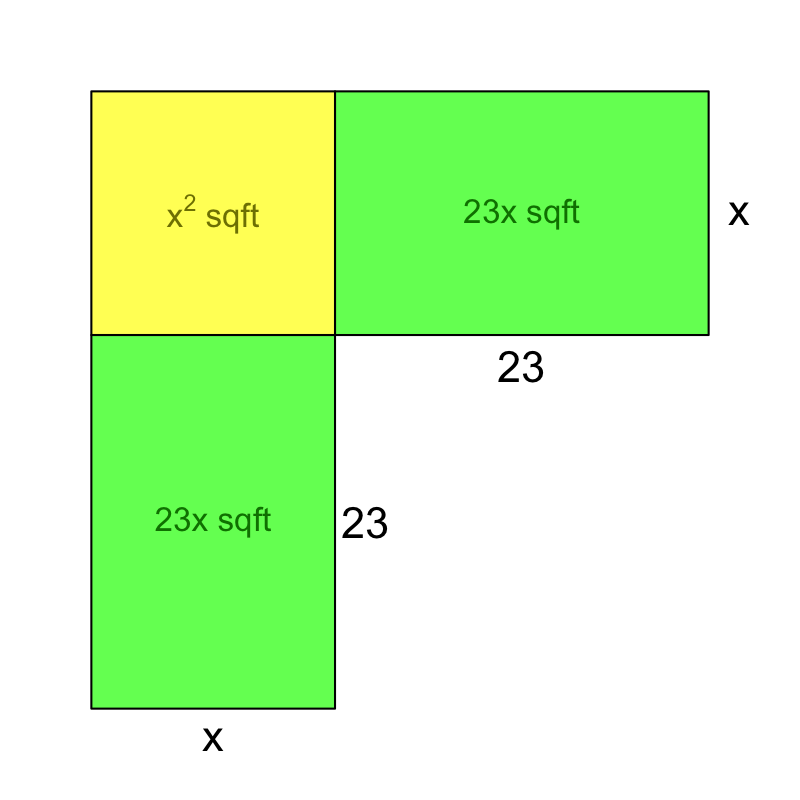

$$x^2+23x+23x~=~915$$

Combine like terms.

$$x^2+46x~=~915$$

There is a fun way to solve this. We will "complete the square". In this situation, the means we can imagine adding some extra area to the picture to make a large square. In this case, we need to add a square with edge lengths of 23, adding 529 square feet to the area.

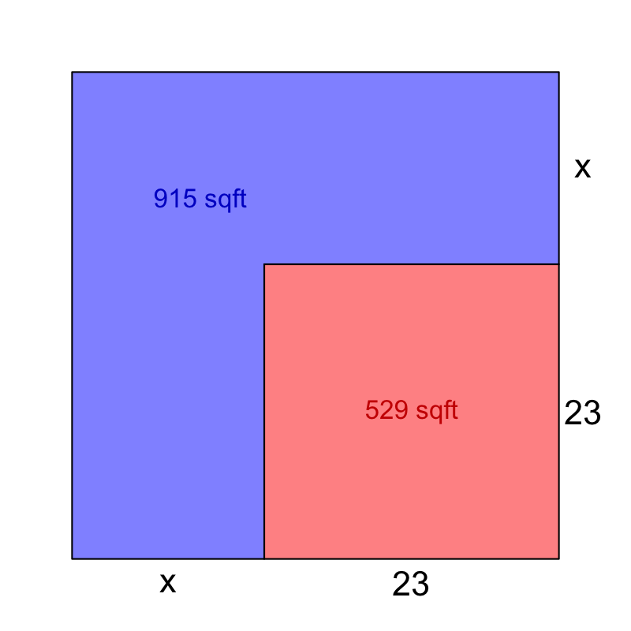

$$x^2+46x+529~=~915+529$$

$$x^2+46x+529~=~1444$$

But, notice, if you look at the last picture, we have another way to represent the total area. The newly formed large square has side lengths of $x+23$. So we can represent the total area of the large square as $(x+23)^2$.

$$(x+23)^2~=~1444$$

We can now use the square-root operation on both sides of the equation.

$$\sqrt{(x+23)^2}~=~\sqrt{1444}$$

$$x+23~=~38$$

And, lastly, subtract 23 from both sides of the equation.

$$x~=~38-23$$

$$x~=~15$$

By [completing the square](https://en.wikipedia.org/wiki/Completing_the_square), find the positive solution to the given equation:

$$x^2+10x~=~39$$

The given equation:

$$x^2+10x~=~39$$

We can visualize this as the areas of a small square and two rectangles. Notice we divide the linear coefficient by 2 to find one dimension of the rectangles.

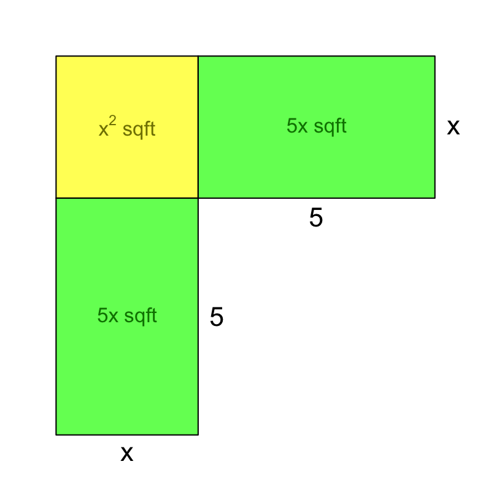

$$x^2+5x+5x~=~39$$

There is a fun way to solve this. We will "complete the square". In this situation, the means we can imagine adding some extra area to the picture to make a large square. In this case, we need to add a square with edge lengths of 5, adding 25 square feet to the area.

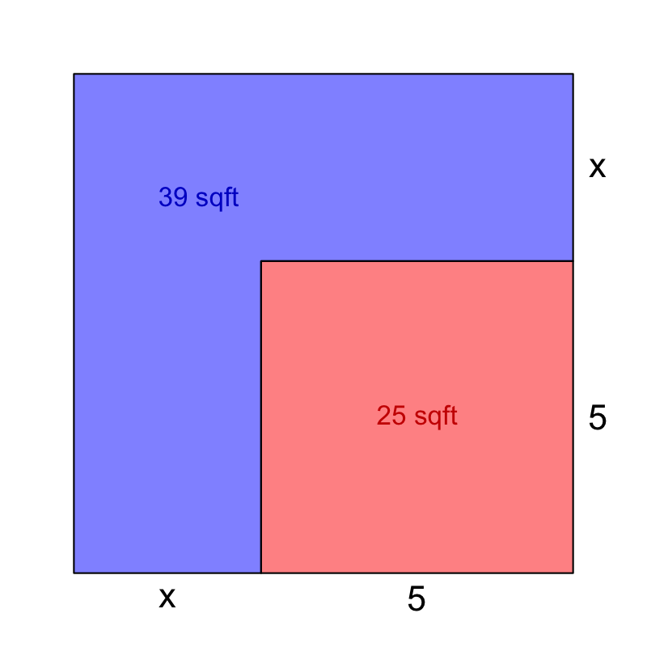

$$x^2+10x+25~=~39+25$$

$$x^2+10x+25~=~64$$

But, notice, if you look at the last picture, we have another way to represent the total area. The newly formed large square has side lengths of $x+5$. So we can represent the total area of the large square as $(x+5)^2$.

$$(x+5)^2~=~64$$

$$x+5~=~\pm 8$$

And, lastly, subtract 5 from both sides of the equation. We only care about the positive solution.

$$x~=~8-5$$

$$x~=~3$$

By [completing the square](https://en.wikipedia.org/wiki/Completing_the_square), find the positive solution to the given equation:

$$x^2+18x~=~144$$

The given equation:

$$x^2+18x~=~144$$

We can visualize this as the areas of a small square and two rectangles. Notice we divide the linear coefficient by 2 to find one dimension of the rectangles.

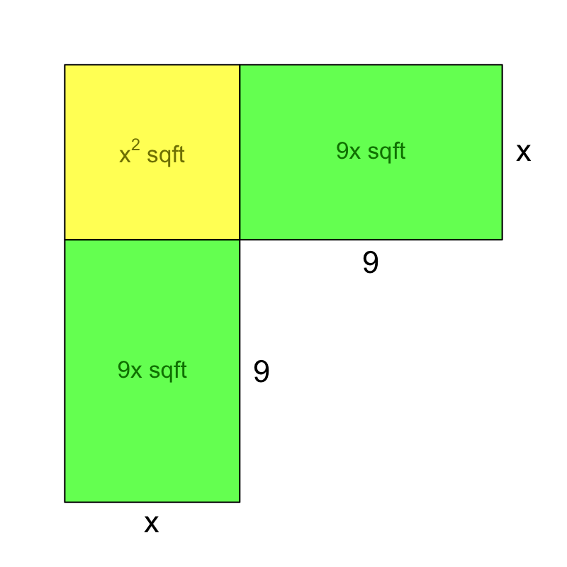

$$x^2+9x+9x~=~144$$

There is a fun way to solve this. We will "complete the square". In this situation, the means we can imagine adding some extra area to the picture to make a large square. In this case, we need to add a square with edge lengths of 9, adding 81 square feet to the area.

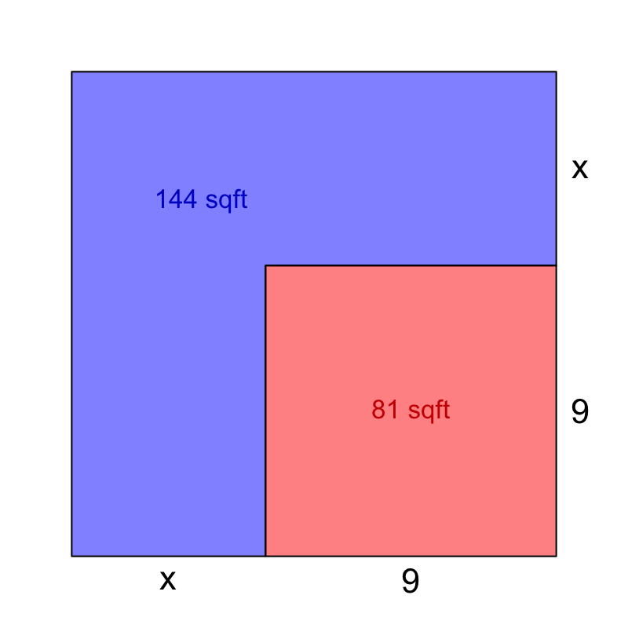

$$x^2+18x+81~=~144+81$$

$$x^2+18x+81~=~225$$

But, notice, if you look at the last picture, we have another way to represent the total area. The newly formed large square has side lengths of $x+9$. So we can represent the total area of the large square as $(x+9)^2$.

$$(x+9)^2~=~225$$

$$x+9~=~\pm 15$$

And, lastly, subtract 9 from both sides of the equation. We only care about the positive solution.

$$x~=~15-9$$

$$x~=~6$$

By [completing the square](https://en.wikipedia.org/wiki/Completing_the_square), find the positive solution to the given equation:

$$x^2+18x~=~115$$

The given equation:

$$x^2+18x~=~115$$

We can visualize this as the areas of a small square and two rectangles. Notice we divide the linear coefficient by 2 to find one dimension of the rectangles.

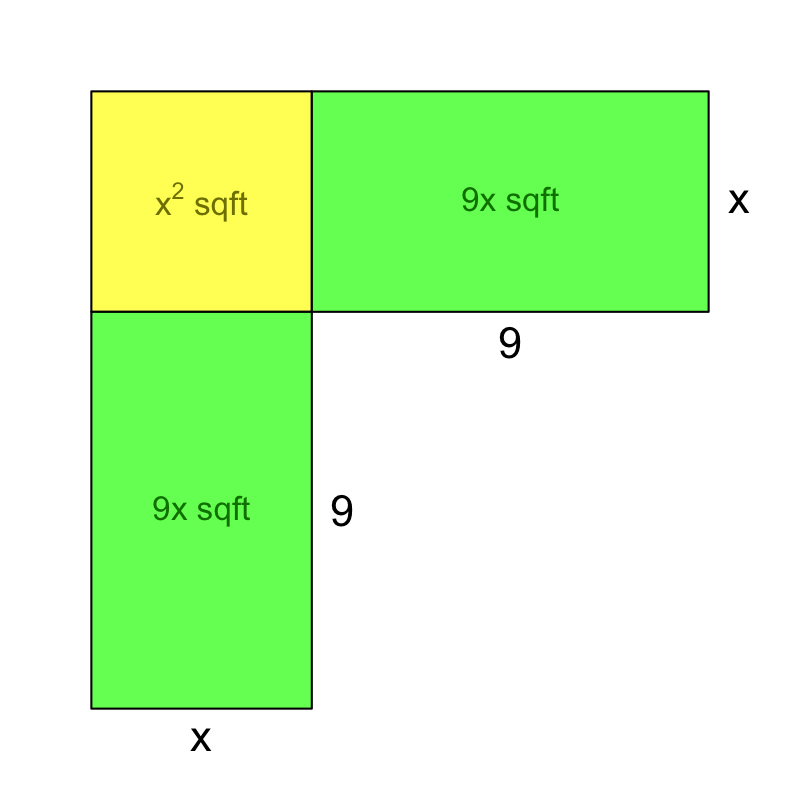

$$x^2+9x+9x~=~115$$

There is a fun way to solve this. We will "complete the square". In this situation, the means we can imagine adding some extra area to the picture to make a large square. In this case, we need to add a square with edge lengths of 9, adding 81 square feet to the area.

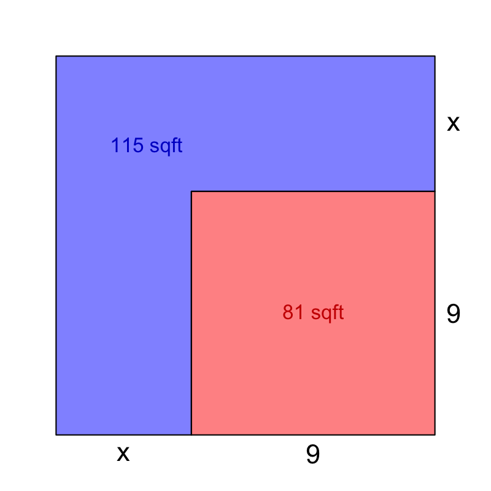

$$x^2+18x+81~=~115+81$$

$$x^2+18x+81~=~196$$

But, notice, if you look at the last picture, we have another way to represent the total area. The newly formed large square has side lengths of $x+9$. So we can represent the total area of the large square as $(x+9)^2$.

$$(x+9)^2~=~196$$

$$x+9~=~\pm 14$$

And, lastly, subtract 9 from both sides of the equation. We only care about the positive solution.

$$x~=~14-9$$

$$x~=~5$$

By [completing the square](https://en.wikipedia.org/wiki/Completing_the_square), find the positive solution to the given equation:

$$x^2+6x~=~91$$

The given equation:

$$x^2+6x~=~91$$

We can visualize this as the areas of a small square and two rectangles. Notice we divide the linear coefficient by 2 to find one dimension of the rectangles.

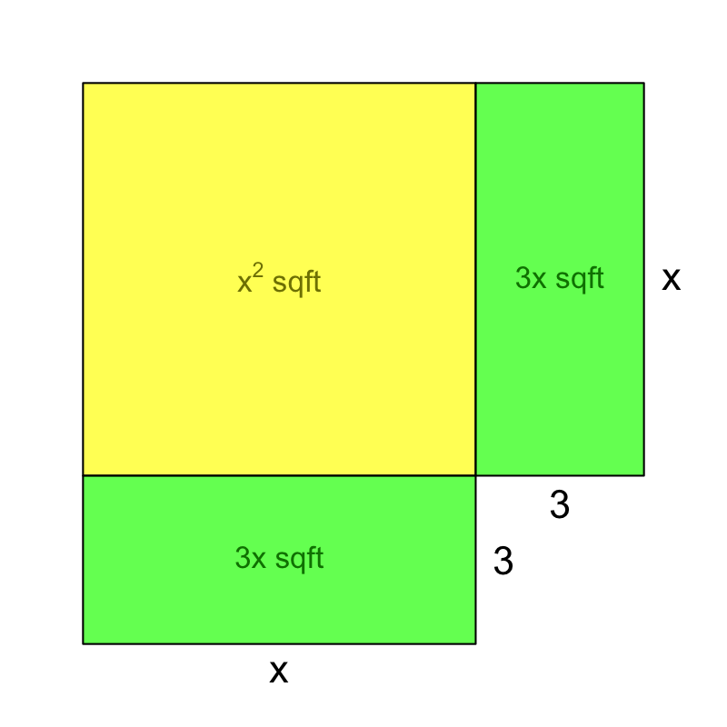

$$x^2+3x+3x~=~91$$

There is a fun way to solve this. We will "complete the square". In this situation, the means we can imagine adding some extra area to the picture to make a large square. In this case, we need to add a square with edge lengths of 3, adding 9 square feet to the area.

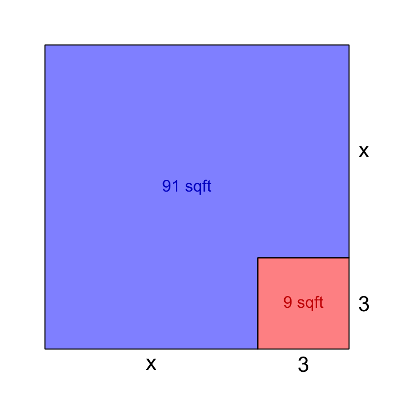

$$x^2+6x+9~=~91+9$$

$$x^2+6x+9~=~100$$

But, notice, if you look at the last picture, we have another way to represent the total area. The newly formed large square has side lengths of $x+3$. So we can represent the total area of the large square as $(x+3)^2$.

$$(x+3)^2~=~100$$

$$x+3~=~\pm 10$$

And, lastly, subtract 3 from both sides of the equation. We only care about the positive solution.

$$x~=~10-3$$

$$x~=~7$$

By [completing the square](https://en.wikipedia.org/wiki/Completing_the_square), find the positive solution to the given equation:

$$x^2+18x~=~63$$

The given equation:

$$x^2+18x~=~63$$

We can visualize this as the areas of a small square and two rectangles. Notice we divide the linear coefficient by 2 to find one dimension of the rectangles.

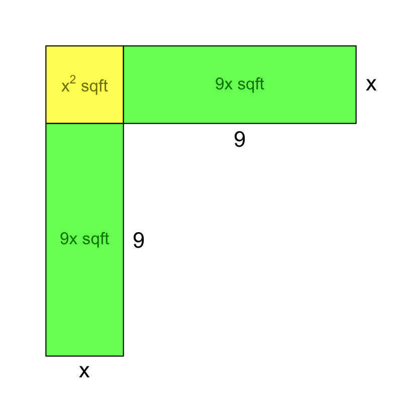

$$x^2+9x+9x~=~63$$

There is a fun way to solve this. We will "complete the square". In this situation, the means we can imagine adding some extra area to the picture to make a large square. In this case, we need to add a square with edge lengths of 9, adding 81 square feet to the area.

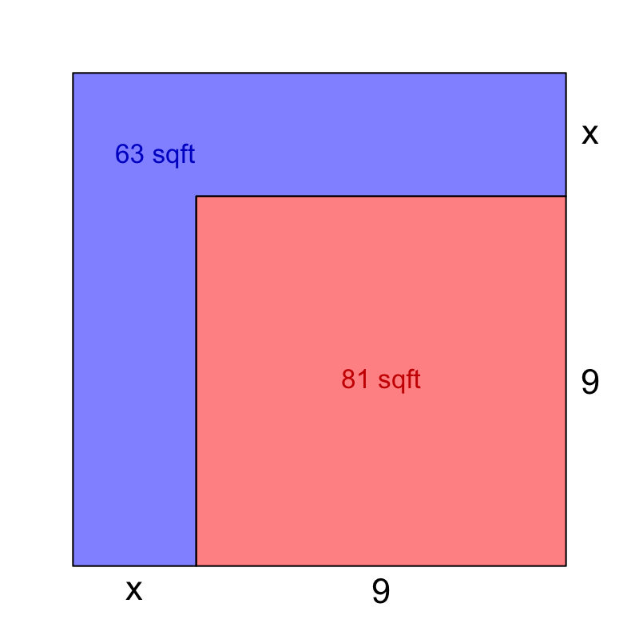

$$x^2+18x+81~=~63+81$$

$$x^2+18x+81~=~144$$

But, notice, if you look at the last picture, we have another way to represent the total area. The newly formed large square has side lengths of $x+9$. So we can represent the total area of the large square as $(x+9)^2$.

$$(x+9)^2~=~144$$

$$x+9~=~\pm 12$$

And, lastly, subtract 9 from both sides of the equation. We only care about the positive solution.

$$x~=~12-9$$

$$x~=~3$$

By [completing the square](https://en.wikipedia.org/wiki/Completing_the_square), find the positive solution to the given equation:

$$x^2+8x~=~84$$

The given equation:

$$x^2+8x~=~84$$

We can visualize this as the areas of a small square and two rectangles. Notice we divide the linear coefficient by 2 to find one dimension of the rectangles.

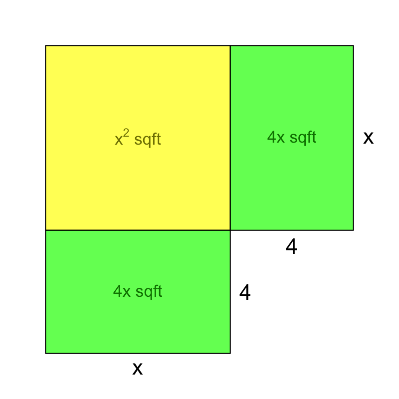

$$x^2+4x+4x~=~84$$

There is a fun way to solve this. We will "complete the square". In this situation, the means we can imagine adding some extra area to the picture to make a large square. In this case, we need to add a square with edge lengths of 4, adding 16 square feet to the area.

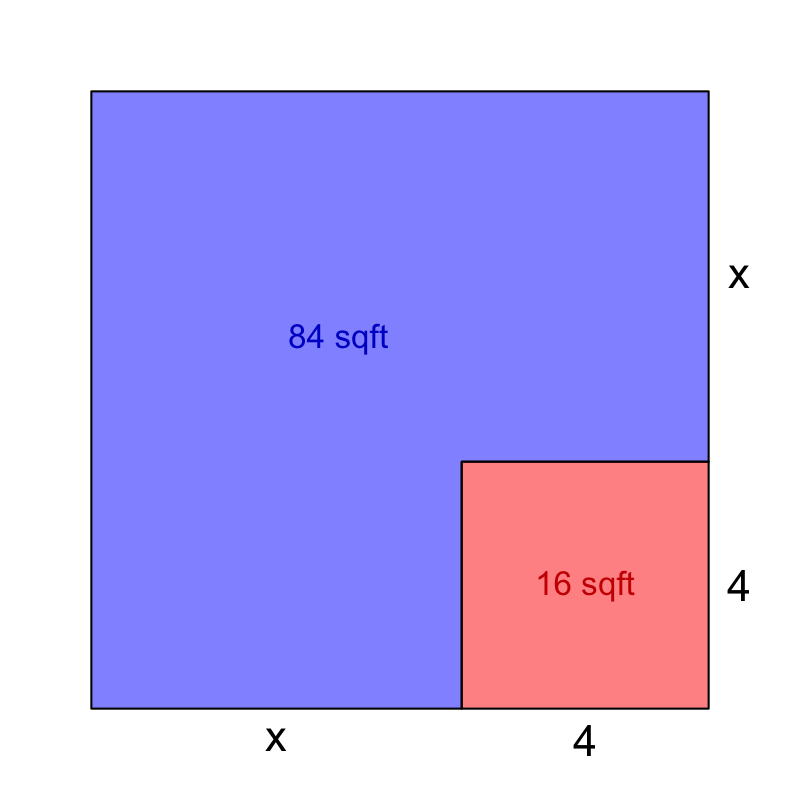

$$x^2+8x+16~=~84+16$$

$$x^2+8x+16~=~100$$

But, notice, if you look at the last picture, we have another way to represent the total area. The newly formed large square has side lengths of $x+4$. So we can represent the total area of the large square as $(x+4)^2$.

$$(x+4)^2~=~100$$

$$x+4~=~\pm 10$$

And, lastly, subtract 4 from both sides of the equation. We only care about the positive solution.

$$x~=~10-4$$

$$x~=~6$$

By [completing the square](https://en.wikipedia.org/wiki/Completing_the_square), find the positive solution to the given equation:

$$x^2+16x~=~57$$

The given equation:

$$x^2+16x~=~57$$

We can visualize this as the areas of a small square and two rectangles. Notice we divide the linear coefficient by 2 to find one dimension of the rectangles.

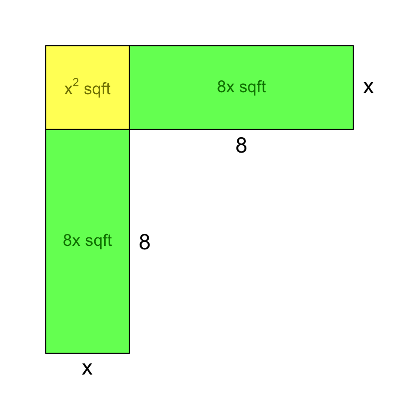

$$x^2+8x+8x~=~57$$

There is a fun way to solve this. We will "complete the square". In this situation, the means we can imagine adding some extra area to the picture to make a large square. In this case, we need to add a square with edge lengths of 8, adding 64 square feet to the area.

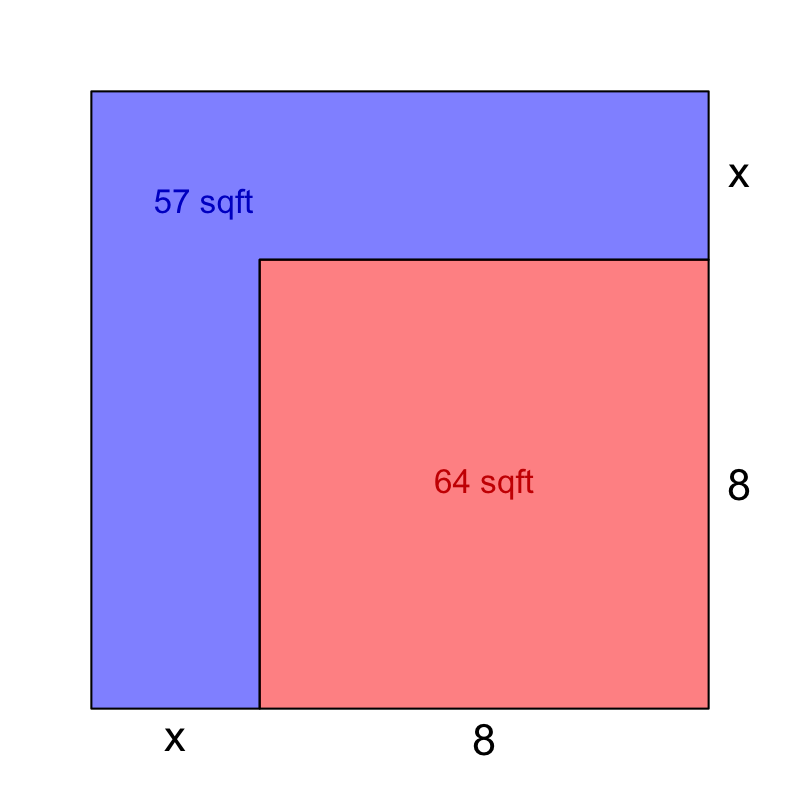

$$x^2+16x+64~=~57+64$$

$$x^2+16x+64~=~121$$

But, notice, if you look at the last picture, we have another way to represent the total area. The newly formed large square has side lengths of $x+8$. So we can represent the total area of the large square as $(x+8)^2$.

$$(x+8)^2~=~121$$

$$x+8~=~\pm 11$$

And, lastly, subtract 8 from both sides of the equation. We only care about the positive solution.

$$x~=~11-8$$

$$x~=~3$$

By [completing the square](https://en.wikipedia.org/wiki/Completing_the_square), find the positive solution to the given equation:

$$x^2+14x~=~51$$

The given equation:

$$x^2+14x~=~51$$

We can visualize this as the areas of a small square and two rectangles. Notice we divide the linear coefficient by 2 to find one dimension of the rectangles.

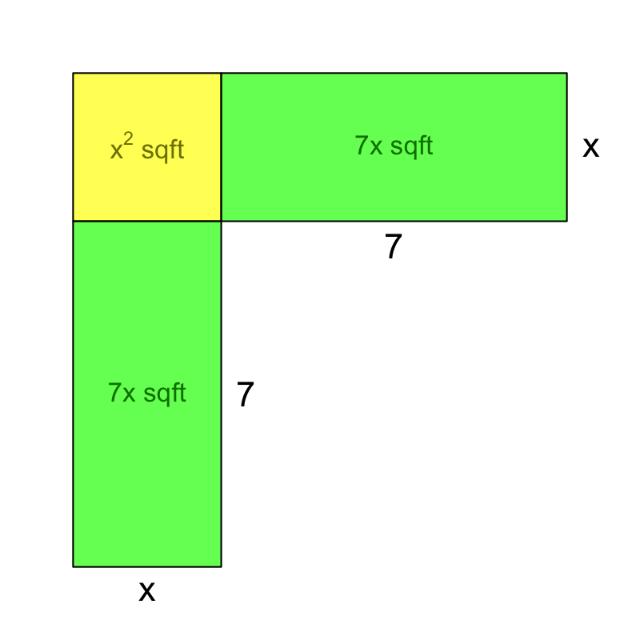

$$x^2+7x+7x~=~51$$

There is a fun way to solve this. We will "complete the square". In this situation, the means we can imagine adding some extra area to the picture to make a large square. In this case, we need to add a square with edge lengths of 7, adding 49 square feet to the area.

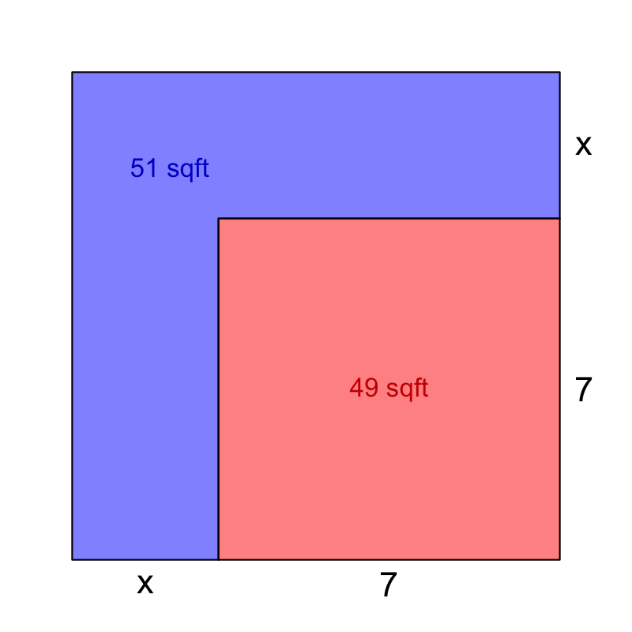

$$x^2+14x+49~=~51+49$$

$$x^2+14x+49~=~100$$

But, notice, if you look at the last picture, we have another way to represent the total area. The newly formed large square has side lengths of $x+7$. So we can represent the total area of the large square as $(x+7)^2$.

$$(x+7)^2~=~100$$

$$x+7~=~\pm 10$$

And, lastly, subtract 7 from both sides of the equation. We only care about the positive solution.

$$x~=~10-7$$

$$x~=~3$$

By [completing the square](https://en.wikipedia.org/wiki/Completing_the_square), find the positive solution to the given equation:

$$x^2+14x~=~176$$

The given equation:

$$x^2+14x~=~176$$

We can visualize this as the areas of a small square and two rectangles. Notice we divide the linear coefficient by 2 to find one dimension of the rectangles.

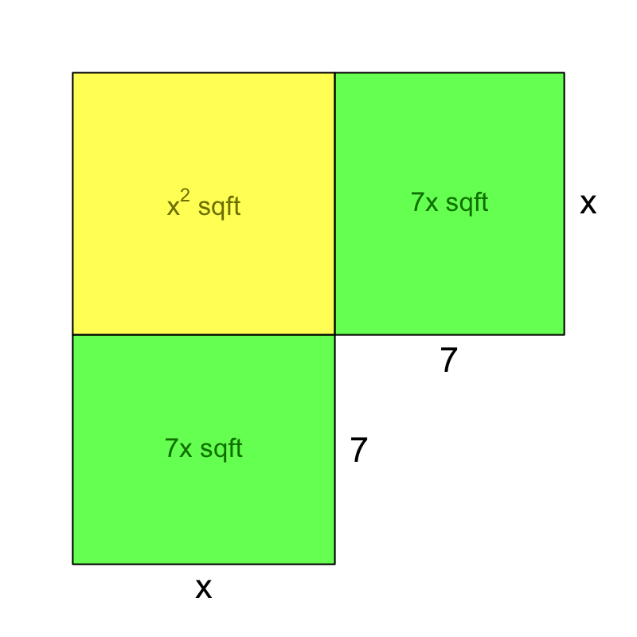

$$x^2+7x+7x~=~176$$

There is a fun way to solve this. We will "complete the square". In this situation, the means we can imagine adding some extra area to the picture to make a large square. In this case, we need to add a square with edge lengths of 7, adding 49 square feet to the area.

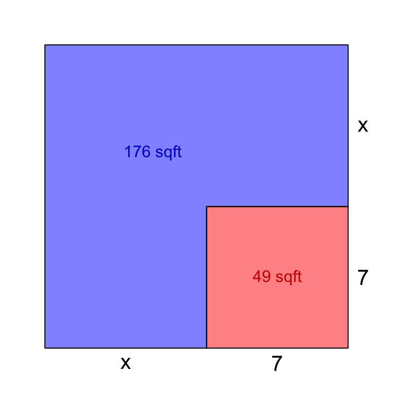

$$x^2+14x+49~=~176+49$$

$$x^2+14x+49~=~225$$

But, notice, if you look at the last picture, we have another way to represent the total area. The newly formed large square has side lengths of $x+7$. So we can represent the total area of the large square as $(x+7)^2$.

$$(x+7)^2~=~225$$

$$x+7~=~\pm 15$$

And, lastly, subtract 7 from both sides of the equation. We only care about the positive solution.

$$x~=~15-7$$

$$x~=~8$$

By [completing the square](https://en.wikipedia.org/wiki/Completing_the_square), find the positive solution to the given equation:

$$x^2+6x~=~135$$

The given equation:

$$x^2+6x~=~135$$

We can visualize this as the areas of a small square and two rectangles. Notice we divide the linear coefficient by 2 to find one dimension of the rectangles.

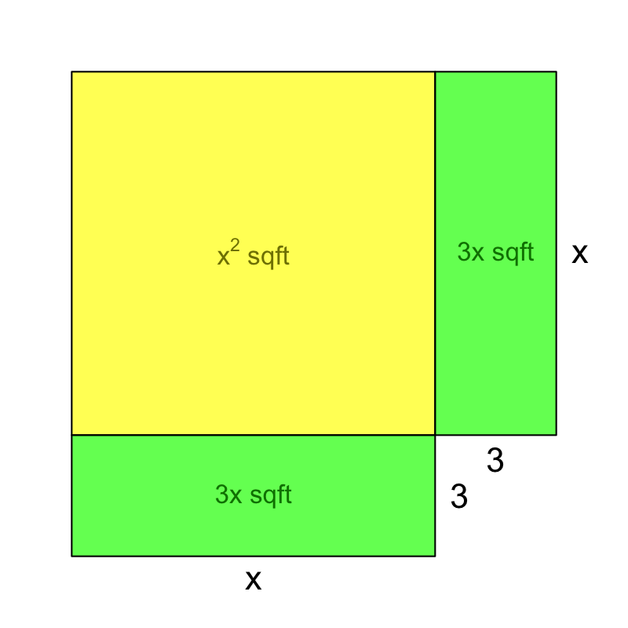

$$x^2+3x+3x~=~135$$

There is a fun way to solve this. We will "complete the square". In this situation, the means we can imagine adding some extra area to the picture to make a large square. In this case, we need to add a square with edge lengths of 3, adding 9 square feet to the area.

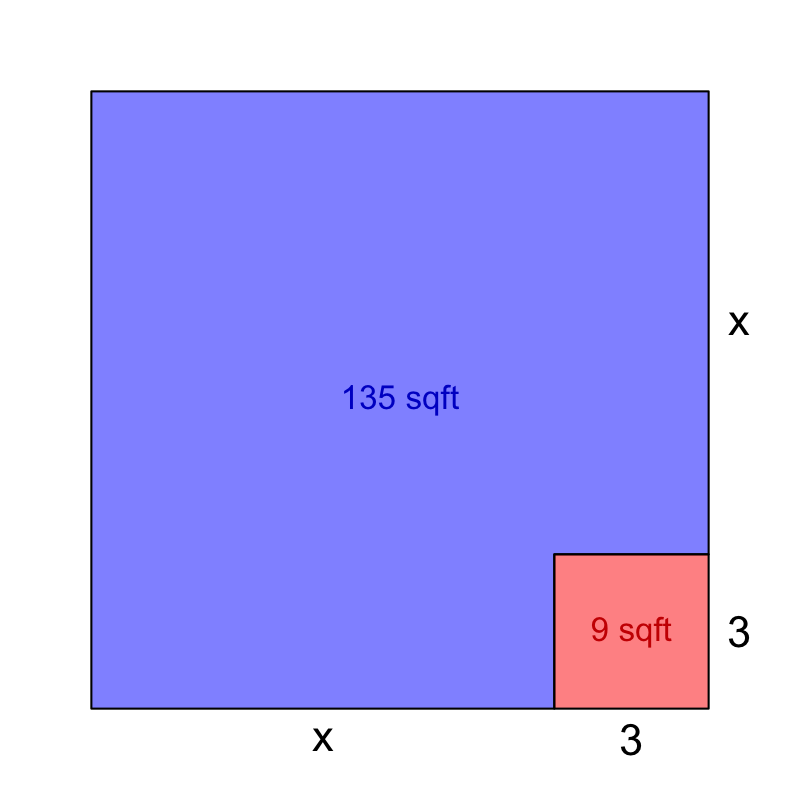

$$x^2+6x+9~=~135+9$$

$$x^2+6x+9~=~144$$

But, notice, if you look at the last picture, we have another way to represent the total area. The newly formed large square has side lengths of $x+3$. So we can represent the total area of the large square as $(x+3)^2$.

$$(x+3)^2~=~144$$

$$x+3~=~\pm 12$$

And, lastly, subtract 3 from both sides of the equation. We only care about the positive solution.

$$x~=~12-3$$

$$x~=~9$$

By [completing the square](https://en.wikipedia.org/wiki/Completing_the_square), find the positive solution to the given equation:

$$x^2+10x~=~144$$

The given equation:

$$x^2+10x~=~144$$

We can visualize this as the areas of a small square and two rectangles. Notice we divide the linear coefficient by 2 to find one dimension of the rectangles.

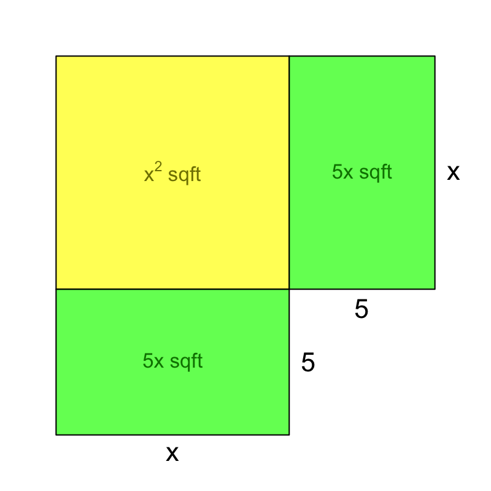

$$x^2+5x+5x~=~144$$

There is a fun way to solve this. We will "complete the square". In this situation, the means we can imagine adding some extra area to the picture to make a large square. In this case, we need to add a square with edge lengths of 5, adding 25 square feet to the area.

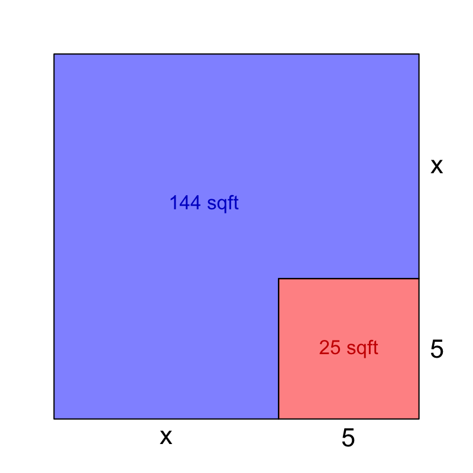

$$x^2+10x+25~=~144+25$$

$$x^2+10x+25~=~169$$

But, notice, if you look at the last picture, we have another way to represent the total area. The newly formed large square has side lengths of $x+5$. So we can represent the total area of the large square as $(x+5)^2$.

$$(x+5)^2~=~169$$

$$x+5~=~\pm 13$$

And, lastly, subtract 5 from both sides of the equation. We only care about the positive solution.

$$x~=~13-5$$

$$x~=~8$$

By [completing the square](https://en.wikipedia.org/wiki/Completing_the_square), find the positive solution to the given equation:

$$x^2+18x~=~175$$

The given equation:

$$x^2+18x~=~175$$

We can visualize this as the areas of a small square and two rectangles. Notice we divide the linear coefficient by 2 to find one dimension of the rectangles.

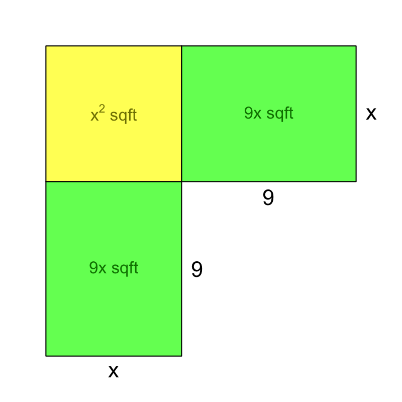

$$x^2+9x+9x~=~175$$

There is a fun way to solve this. We will "complete the square". In this situation, the means we can imagine adding some extra area to the picture to make a large square. In this case, we need to add a square with edge lengths of 9, adding 81 square feet to the area.

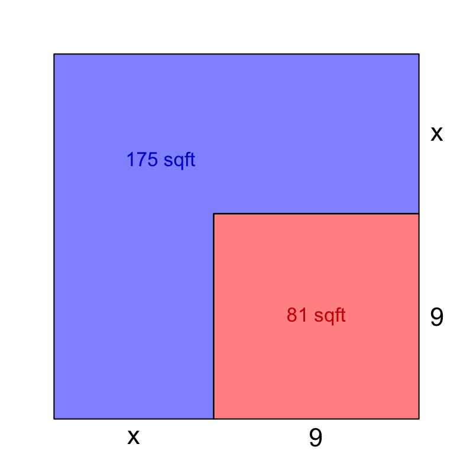

$$x^2+18x+81~=~175+81$$

$$x^2+18x+81~=~256$$

But, notice, if you look at the last picture, we have another way to represent the total area. The newly formed large square has side lengths of $x+9$. So we can represent the total area of the large square as $(x+9)^2$.

$$(x+9)^2~=~256$$

$$x+9~=~\pm 16$$

And, lastly, subtract 9 from both sides of the equation. We only care about the positive solution.

$$x~=~16-9$$

$$x~=~7$$

By [completing the square](https://en.wikipedia.org/wiki/Completing_the_square), find both solutions to the given equation:

$$x^2-16x~=~80$$

The given equation:

$$x^2-16x~=~80$$

In order to make the left side of the equation a [perfect square](https://www.khanacademy.org/math/math2/xe2ae2386aa2e13d6:quad-1/xe2ae2386aa2e13d6:perfect-sq/a/factoring-quadratics-perfect-squares), we can add $\left(\frac{-16}{2}\right)^2=64$ to both sides (where -16 is the linear coefficient).

$$x^2-16x+64~=~80+64$$

$$x^2-16x+64~=~144$$

We can rewrite the left side in factored form. Notice that because the left side is a perfect square, we get a squared binomial.

$$(x-8)^2~=~144$$

Because the squaring function is not one-to-one, when we "undo" it in algebra, we need to consider the possibility of multiple solutions. In this case both 12 and -12 produce 144 when squared.

$$x-8~=~\pm 12$$

And, lastly, subtract -8 from both sides of the equation.

$$x~=~\pm12+8$$

$$x~=~20~~~~~~~~\text{or}~~~~~~~~x~=~-4$$

By [completing the square](https://en.wikipedia.org/wiki/Completing_the_square), find both solutions to the given equation:

$$x^2-8x~=~65$$

The given equation:

$$x^2-8x~=~65$$

In order to make the left side of the equation a [perfect square](https://www.khanacademy.org/math/math2/xe2ae2386aa2e13d6:quad-1/xe2ae2386aa2e13d6:perfect-sq/a/factoring-quadratics-perfect-squares), we can add $\left(\frac{-8}{2}\right)^2=16$ to both sides (where -8 is the linear coefficient).

$$x^2-8x+16~=~65+16$$

$$x^2-8x+16~=~81$$

We can rewrite the left side in factored form. Notice that because the left side is a perfect square, we get a squared binomial.

$$(x-4)^2~=~81$$

Because the squaring function is not one-to-one, when we "undo" it in algebra, we need to consider the possibility of multiple solutions. In this case both 9 and -9 produce 81 when squared.

$$x-4~=~\pm 9$$

And, lastly, subtract -4 from both sides of the equation.

$$x~=~\pm9+4$$

$$x~=~13~~~~~~~~\text{or}~~~~~~~~x~=~-5$$

By [completing the square](https://en.wikipedia.org/wiki/Completing_the_square), find both solutions to the given equation:

$$x^2-8x~=~0$$

The given equation:

$$x^2-8x~=~0$$

In order to make the left side of the equation a [perfect square](https://www.khanacademy.org/math/math2/xe2ae2386aa2e13d6:quad-1/xe2ae2386aa2e13d6:perfect-sq/a/factoring-quadratics-perfect-squares), we can add $\left(\frac{-8}{2}\right)^2=16$ to both sides (where -8 is the linear coefficient).

$$x^2-8x+16~=~16$$

$$x^2-8x+16~=~16$$

We can rewrite the left side in factored form. Notice that because the left side is a perfect square, we get a squared binomial.

$$(x-4)^2~=~16$$

Because the squaring function is not one-to-one, when we "undo" it in algebra, we need to consider the possibility of multiple solutions. In this case both 4 and -4 produce 16 when squared.

$$x-4~=~\pm 4$$

And, lastly, subtract -4 from both sides of the equation.

$$x~=~\pm4+4$$

$$x~=~8~~~~~~~~\text{or}~~~~~~~~x~=~0$$

By [completing the square](https://en.wikipedia.org/wiki/Completing_the_square), find both solutions to the given equation:

$$x^2-8x~=~65$$

The given equation:

$$x^2-8x~=~65$$

In order to make the left side of the equation a [perfect square](https://www.khanacademy.org/math/math2/xe2ae2386aa2e13d6:quad-1/xe2ae2386aa2e13d6:perfect-sq/a/factoring-quadratics-perfect-squares), we can add $\left(\frac{-8}{2}\right)^2=16$ to both sides (where -8 is the linear coefficient).

$$x^2-8x+16~=~65+16$$

$$x^2-8x+16~=~81$$

We can rewrite the left side in factored form. Notice that because the left side is a perfect square, we get a squared binomial.

$$(x-4)^2~=~81$$

Because the squaring function is not one-to-one, when we "undo" it in algebra, we need to consider the possibility of multiple solutions. In this case both 9 and -9 produce 81 when squared.

$$x-4~=~\pm 9$$

And, lastly, subtract -4 from both sides of the equation.

$$x~=~\pm9+4$$

$$x~=~13~~~~~~~~\text{or}~~~~~~~~x~=~-5$$

By [completing the square](https://en.wikipedia.org/wiki/Completing_the_square), find both solutions to the given equation:

$$x^2+6x~=~91$$

The given equation:

$$x^2+6x~=~91$$

In order to make the left side of the equation a [perfect square](https://www.khanacademy.org/math/math2/xe2ae2386aa2e13d6:quad-1/xe2ae2386aa2e13d6:perfect-sq/a/factoring-quadratics-perfect-squares), we can add $\left(\frac{6}{2}\right)^2=9$ to both sides (where 6 is the linear coefficient).

$$x^2+6x+9~=~91+9$$

$$x^2+6x+9~=~100$$

We can rewrite the left side in factored form. Notice that because the left side is a perfect square, we get a squared binomial.

$$(x+3)^2~=~100$$

Because the squaring function is not one-to-one, when we "undo" it in algebra, we need to consider the possibility of multiple solutions. In this case both 10 and -10 produce 100 when squared.

$$x+3~=~\pm 10$$

And, lastly, subtract 3 from both sides of the equation.

$$x~=~\pm10-3$$

$$x~=~7~~~~~~~~\text{or}~~~~~~~~x~=~-13$$

By [completing the square](https://en.wikipedia.org/wiki/Completing_the_square), find both solutions to the given equation:

$$x^2+8x~=~105$$

The given equation:

$$x^2+8x~=~105$$

In order to make the left side of the equation a [perfect square](https://www.khanacademy.org/math/math2/xe2ae2386aa2e13d6:quad-1/xe2ae2386aa2e13d6:perfect-sq/a/factoring-quadratics-perfect-squares), we can add $\left(\frac{8}{2}\right)^2=16$ to both sides (where 8 is the linear coefficient).

$$x^2+8x+16~=~105+16$$

$$x^2+8x+16~=~121$$

We can rewrite the left side in factored form. Notice that because the left side is a perfect square, we get a squared binomial.

$$(x+4)^2~=~121$$

Because the squaring function is not one-to-one, when we "undo" it in algebra, we need to consider the possibility of multiple solutions. In this case both 11 and -11 produce 121 when squared.

$$x+4~=~\pm 11$$

And, lastly, subtract 4 from both sides of the equation.

$$x~=~\pm11-4$$

$$x~=~7~~~~~~~~\text{or}~~~~~~~~x~=~-15$$

By [completing the square](https://en.wikipedia.org/wiki/Completing_the_square), find both solutions to the given equation:

$$x^2+8x~=~-7$$

The given equation:

$$x^2+8x~=~-7$$

In order to make the left side of the equation a [perfect square](https://www.khanacademy.org/math/math2/xe2ae2386aa2e13d6:quad-1/xe2ae2386aa2e13d6:perfect-sq/a/factoring-quadratics-perfect-squares), we can add $\left(\frac{8}{2}\right)^2=16$ to both sides (where 8 is the linear coefficient).

$$x^2+8x+16~=~-7+16$$

$$x^2+8x+16~=~9$$

We can rewrite the left side in factored form. Notice that because the left side is a perfect square, we get a squared binomial.

$$(x+4)^2~=~9$$

Because the squaring function is not one-to-one, when we "undo" it in algebra, we need to consider the possibility of multiple solutions. In this case both 3 and -3 produce 9 when squared.

$$x+4~=~\pm 3$$

And, lastly, subtract 4 from both sides of the equation.

$$x~=~\pm3-4$$

$$x~=~-1~~~~~~~~\text{or}~~~~~~~~x~=~-7$$

By [completing the square](https://en.wikipedia.org/wiki/Completing_the_square), find both solutions to the given equation:

$$x^2-12x~=~160$$

The given equation:

$$x^2-12x~=~160$$

In order to make the left side of the equation a [perfect square](https://www.khanacademy.org/math/math2/xe2ae2386aa2e13d6:quad-1/xe2ae2386aa2e13d6:perfect-sq/a/factoring-quadratics-perfect-squares), we can add $\left(\frac{-12}{2}\right)^2=36$ to both sides (where -12 is the linear coefficient).

$$x^2-12x+36~=~160+36$$

$$x^2-12x+36~=~196$$

We can rewrite the left side in factored form. Notice that because the left side is a perfect square, we get a squared binomial.

$$(x-6)^2~=~196$$

Because the squaring function is not one-to-one, when we "undo" it in algebra, we need to consider the possibility of multiple solutions. In this case both 14 and -14 produce 196 when squared.

$$x-6~=~\pm 14$$

And, lastly, subtract -6 from both sides of the equation.

$$x~=~\pm14+6$$

$$x~=~20~~~~~~~~\text{or}~~~~~~~~x~=~-8$$

By [completing the square](https://en.wikipedia.org/wiki/Completing_the_square), find both solutions to the given equation:

$$x^2+18x~=~144$$

The given equation:

$$x^2+18x~=~144$$

In order to make the left side of the equation a [perfect square](https://www.khanacademy.org/math/math2/xe2ae2386aa2e13d6:quad-1/xe2ae2386aa2e13d6:perfect-sq/a/factoring-quadratics-perfect-squares), we can add $\left(\frac{18}{2}\right)^2=81$ to both sides (where 18 is the linear coefficient).

$$x^2+18x+81~=~144+81$$

$$x^2+18x+81~=~225$$

We can rewrite the left side in factored form. Notice that because the left side is a perfect square, we get a squared binomial.

$$(x+9)^2~=~225$$

Because the squaring function is not one-to-one, when we "undo" it in algebra, we need to consider the possibility of multiple solutions. In this case both 15 and -15 produce 225 when squared.

$$x+9~=~\pm 15$$

And, lastly, subtract 9 from both sides of the equation.

$$x~=~\pm15-9$$

$$x~=~6~~~~~~~~\text{or}~~~~~~~~x~=~-24$$

By [completing the square](https://en.wikipedia.org/wiki/Completing_the_square), find both solutions to the given equation:

$$x^2-12x~=~45$$

The given equation:

$$x^2-12x~=~45$$

In order to make the left side of the equation a [perfect square](https://www.khanacademy.org/math/math2/xe2ae2386aa2e13d6:quad-1/xe2ae2386aa2e13d6:perfect-sq/a/factoring-quadratics-perfect-squares), we can add $\left(\frac{-12}{2}\right)^2=36$ to both sides (where -12 is the linear coefficient).

$$x^2-12x+36~=~45+36$$

$$x^2-12x+36~=~81$$

We can rewrite the left side in factored form. Notice that because the left side is a perfect square, we get a squared binomial.

$$(x-6)^2~=~81$$

Because the squaring function is not one-to-one, when we "undo" it in algebra, we need to consider the possibility of multiple solutions. In this case both 9 and -9 produce 81 when squared.

$$x-6~=~\pm 9$$

And, lastly, subtract -6 from both sides of the equation.

$$x~=~\pm9+6$$

$$x~=~15~~~~~~~~\text{or}~~~~~~~~x~=~-3$$

By [completing the square](https://en.wikipedia.org/wiki/Completing_the_square), find both solutions to the given equation:

$$x^2-12x~=~-27$$

The given equation:

$$x^2-12x~=~-27$$

In order to make the left side of the equation a [perfect square](https://www.khanacademy.org/math/math2/xe2ae2386aa2e13d6:quad-1/xe2ae2386aa2e13d6:perfect-sq/a/factoring-quadratics-perfect-squares), we can add $\left(\frac{-12}{2}\right)^2=36$ to both sides (where -12 is the linear coefficient).

$$x^2-12x+36~=~-27+36$$

$$x^2-12x+36~=~9$$

We can rewrite the left side in factored form. Notice that because the left side is a perfect square, we get a squared binomial.

$$(x-6)^2~=~9$$

Because the squaring function is not one-to-one, when we "undo" it in algebra, we need to consider the possibility of multiple solutions. In this case both 3 and -3 produce 9 when squared.

$$x-6~=~\pm 3$$

And, lastly, subtract -6 from both sides of the equation.

$$x~=~\pm3+6$$

$$x~=~9~~~~~~~~\text{or}~~~~~~~~x~=~3$$

By [completing the square](https://en.wikipedia.org/wiki/Completing_the_square), find both solutions to the given equation:

$$x^2-8x~=~-7$$

The given equation:

$$x^2-8x~=~-7$$

In order to make the left side of the equation a [perfect square](https://www.khanacademy.org/math/math2/xe2ae2386aa2e13d6:quad-1/xe2ae2386aa2e13d6:perfect-sq/a/factoring-quadratics-perfect-squares), we can add $\left(\frac{-8}{2}\right)^2=16$ to both sides (where -8 is the linear coefficient).

$$x^2-8x+16~=~-7+16$$

$$x^2-8x+16~=~9$$

We can rewrite the left side in factored form. Notice that because the left side is a perfect square, we get a squared binomial.

$$(x-4)^2~=~9$$

Because the squaring function is not one-to-one, when we "undo" it in algebra, we need to consider the possibility of multiple solutions. In this case both 3 and -3 produce 9 when squared.

$$x-4~=~\pm 3$$

And, lastly, subtract -4 from both sides of the equation.

$$x~=~\pm3+4$$

$$x~=~7~~~~~~~~\text{or}~~~~~~~~x~=~1$$